# TUD FOR WEEKDAYS

Kakau with minor amendments from Ben :-)

Last run at: 2020-05-18 12:10:16

```r
# packages ----
library(plyr)
library(stringr)
library(tidyverse)
library(tidyr)
library(lubridate)
library(kableExtra)
library(dplyr)
library(scales)
```

```r
library(ggplot2)

# parameters ----
dPath <- "/Volumes/hum-csafe/Research Projects/FoliakiPhD/tudData/" # edit for your set up
dataF <- path.expand(paste0(dPath, "TUD Weekdays 050520.csv"))
```

# 1 Time Use Diary

The dataframe is a wide format. I had to clean the data by correcting typo and translating some of the data into english. So the file is not as original as it is when export from qualtrics.

```r
# read in my dataframe
weekdays <- read.csv(dataF, na.strings=c(""), check.names = FALSE, header = TRUE, as.is=TRUE)

head(weekdays)
```

```
##     Village Household ID       Day  3:00 AM  3:30 AM  4:00 AM  4:30 AM
## 1      Fasi           17    Monday Sleeping Sleeping Sleeping Sleeping
## 2      Fasi           17    Monday     <NA>     <NA>     <NA>     <NA>
## 3     Fanga            2    Monday Sleeping Sleeping Sleeping Sleeping
## 4     Fanga            2    Monday     <NA>     <NA>     <NA>     <NA>
## 5 Fangaloto            7 Wednesday Sleeping Sleeping Sleeping Sleeping
## 6 Fangaloto            7 Wednesday     <NA>     <NA>     <NA>     <NA>
##    5:00 AM  5:30 AM  6:00 AM         6:30 AM               7:00 AM
## 1 Sleeping Sleeping  Woke up       Showering             Breakfast
## 2     <NA>     <NA>     <NA> Getting dressed                  <NA>
## 3 Sleeping Sleeping Sleeping        Sleeping               Woke up
## 4     <NA>     <NA>     <NA>            <NA>             Showering
## 5 Sleeping Sleeping Sleeping        Sleeping               Woke up
## 6     <NA>     <NA>     <NA>            <NA> Listen to music/radio
##                 7:30 AM               8:00 AM             8:30 AM 9:00 AM
```

[output cut: 55 more lines]

Converting the wide dataframe to long dataframe for easier analysis

Ive noticed that the time is in a character format rather than date. i need to change it to date

> see below

```r
longweekdays <- weekdays %>%
  gather(Time, Activity, 4:51)

head(longweekdays)
```

```
##     Village Household ID       Day    Time Activity
## 1      Fasi           17    Monday 3:00 AM Sleeping
## 2      Fasi           17    Monday 3:00 AM     <NA>
## 3     Fanga            2    Monday 3:00 AM Sleeping
## 4     Fanga            2    Monday 3:00 AM     <NA>
## 5 Fangaloto            7 Wednesday 3:00 AM Sleeping
## 6 Fangaloto            7 Wednesday 3:00 AM     <NA>
```

Sorting the TUD dataframe, Firstly, as you can see previously some respondents do not have a secondary activity (i.e NA). Secondly, the data is sorted by time. I think it would be easier to sorted by Household ID. So here i am sorting the data based on ID number

```r
# sorting my dataframe in accending order based on the Household ID
weekdayOrder <- order(longweekdays$`Household ID`)
head(weekdayOrder)
```

```
## [1]   3   4 181 182 359 360
```

```r
# Applying the sorting order into my "longweekdends" dataframe and call it sortweekends
sortweekdays <- longweekdays[weekdayOrder,]
head(sortweekdays)
```

```
##     Village Household ID    Day    Time Activity
## 3     Fanga            2 Monday 3:00 AM Sleeping
## 4     Fanga            2 Monday 3:00 AM     <NA>
## 181   Fanga            2 Monday 3:30 AM Sleeping
## 182   Fanga            2 Monday 3:30 AM     <NA>
## 359   Fanga            2 Monday 4:00 AM Sleeping
## 360   Fanga            2 Monday 4:00 AM     <NA>
```

```r
names(sortweekdays)
```

```
## [1] "Village"      "Household ID" "Day"          "Time"
## [5] "Activity"
```

Here i am seprating the activity columm into a primary activity and a secondary activity

The issue im facing with is the date. It in character and alsoit picked up the current date (2020) rather than the date from the TUD.

> BA: I can’t see a date variable. How would R know which date the diary was completed on?

Im trying to sort the date but it comes back N/A

> see below

```r
# Since both the first and second activiies are in one column, i need to separate them into two columns

#call the number of row in my dataframe for the maximum row for my sequence function
nrow(sortweekdays)
```

```
## [1] 8544
```

```r
#create a new dataframe "newdata" for the primary activity only (all odd rows)
newdata <- sortweekdays[seq(1,8543,2),]
head(newdata)
```

```
##     Village Household ID    Day    Time Activity
## 3     Fanga            2 Monday 3:00 AM Sleeping
## 181   Fanga            2 Monday 3:30 AM Sleeping
## 359   Fanga            2 Monday 4:00 AM Sleeping
## 537   Fanga            2 Monday 4:30 AM Sleeping
## 715   Fanga            2 Monday 5:00 AM Sleeping
## 893   Fanga            2 Monday 5:30 AM Sleeping
```

```r
#create a new datagame "newdata1" for the secondary activity (oall even rows)
newdata1 <- sortweekdays[seq(2,8544,2),]
head(newdata1)
```

```
##     Village Household ID    Day    Time Activity
## 4     Fanga            2 Monday 3:00 AM     <NA>
## 182   Fanga            2 Monday 3:30 AM     <NA>
## 360   Fanga            2 Monday 4:00 AM     <NA>
## 538   Fanga            2 Monday 4:30 AM     <NA>
## 716   Fanga            2 Monday 5:00 AM     <NA>
## 894   Fanga            2 Monday 5:30 AM     <NA>
```

```r
#since i have separated my two acitvities, i need to merge them into one dataframe
newdata$Activity2 <- newdata1$Activity

kableExtra::kable(head(newdata), caption = "Test merged long form data") %>%
  kable_styling()
```

Table 1.1: Test merged long form data

|  | Village | Household ID | Day | Time | Activity | Activity2 |
| --- | --- | --- | --- | --- | --- | --- |
| 3 | Fanga | 2 | Monday | 3:00 AM | Sleeping | NA |
| 181 | Fanga | 2 | Monday | 3:30 AM | Sleeping | NA |
| 359 | Fanga | 2 | Monday | 4:00 AM | Sleeping | NA |
| 537 | Fanga | 2 | Monday | 4:30 AM | Sleeping | NA |
| 715 | Fanga | 2 | Monday | 5:00 AM | Sleeping | NA |
| 893 | Fanga | 2 | Monday | 5:30 AM | Sleeping | NA |

> BA: fix the time variable so it looks like and acts like HH:MM

```r
#newdata$rawTime <- hms::parse_hm(newdata$Time) # this will only be right for AM
#newdata$AM_PM <- stringr::word(newdata$Time, 2) # get the second word of 'Time' which will be AM or PM

# better solution
# https://stackoverflow.com/questions/7883806/parse-timestamp-with-a-m-p-m
# this will make it today's date and the current time zone by default
newdata$rawTime <- as.POSIXct(newdata$Time, format="%l:%M %p")

# Lesson #1: always enter times as 24 hour clock: HH:MM !!

# Now use that to add 12 hours to rawTime whenit is actually PM
# newdata$fixedTime <- ifelse(newdata$AM_PM =="PM", # if PM
#                             newdata$rawTime + (12 * 60 * 60), #  add 12 hours
#                             newdata$rawTime # otherwise don't
#                             )
newdata$fixedHMS <- hms::as_hms(newdata$rawTime) # make sure it is in H:M:S format

t <- table(newdata$Time, newdata$rawTime)
kableExtra::kable(t, caption = "Test time coding") %>%
  kable_styling()
```

Table 1.2: Test time coding

|  | 2020-05-18 00:00:00 | 2020-05-18 00:30:00 | 2020-05-18 01:00:00 | 2020-05-18 01:30:00 | 2020-05-18 02:00:00 | 2020-05-18 02:30:00 | 2020-05-18 03:00:00 | 2020-05-18 03:30:00 | 2020-05-18 04:00:00 | 2020-05-18 04:30:00 | 2020-05-18 05:00:00 | 2020-05-18 05:30:00 | 2020-05-18 06:00:00 | 2020-05-18 06:30:00 | 2020-05-18 07:00:00 | 2020-05-18 07:30:00 | 2020-05-18 08:00:00 | 2020-05-18 08:30:00 | 2020-05-18 09:00:00 | 2020-05-18 09:30:00 | 2020-05-18 10:00:00 | 2020-05-18 10:30:00 | 2020-05-18 11:00:00 | 2020-05-18 11:30:00 | 2020-05-18 12:00:00 | 2020-05-18 12:30:00 | 2020-05-18 13:00:00 | 2020-05-18 13:30:00 | 2020-05-18 14:00:00 | … |
| --- | --- | --- | --- | --- | --- | --- | --- | --- | --- | --- | --- | --- | --- | --- | --- | --- | --- | --- | --- | --- | --- | --- | --- | --- | --- | --- | --- | --- | --- | --- |
| 1:00 AM | 0 | 0 | 89 | 0 | 0 | 0 | 0 | 0 | 0 | 0 | 0 | 0 | 0 | 0 | 0 | 0 | 0 | 0 | 0 | 0 | 0 | 0 | 0 | 0 | 0 | 0 | 0 | 0 | 0 | … |
| 1:00 PM | 0 | 0 | 0 | 0 | 0 | 0 | 0 | 0 | 0 | 0 | 0 | 0 | 0 | 0 | 0 | 0 | 0 | 0 | 0 | 0 | 0 | 0 | 0 | 0 | 0 | 0 | 89 | 0 | 0 | … |
| 1:30 AM | 0 | 0 | 0 | 89 | 0 | 0 | 0 | 0 | 0 | 0 | 0 | 0 | 0 | 0 | 0 | 0 | 0 | 0 | 0 | 0 | 0 | 0 | 0 | 0 | 0 | 0 | 0 | 0 | 0 | … |
| 1:30 PM | 0 | 0 | 0 | 0 | 0 | 0 | 0 | 0 | 0 | 0 | 0 | 0 | 0 | 0 | 0 | 0 | 0 | 0 | 0 | 0 | 0 | 0 | 0 | 0 | 0 | 0 | 0 | 89 | 0 | … |
| 10:00 AM | 0 | 0 | 0 | 0 | 0 | 0 | 0 | 0 | 0 | 0 | 0 | 0 | 0 | 0 | 0 | 0 | 0 | 0 | 0 | 0 | 89 | 0 | 0 | 0 | 0 | 0 | 0 | 0 | 0 | … |
| 10:00 PM | 0 | 0 | 0 | 0 | 0 | 0 | 0 | 0 | 0 | 0 | 0 | 0 | 0 | 0 | 0 | 0 | 0 | 0 | 0 | 0 | 0 | 0 | 0 | 0 | 0 | 0 | 0 | 0 | 0 | … |
| 10:30 AM | 0 | 0 | 0 | 0 | 0 | 0 | 0 | 0 | 0 | 0 | 0 | 0 | 0 | 0 | 0 | 0 | 0 | 0 | 0 | 0 | 0 | 89 | 0 | 0 | 0 | 0 | 0 | 0 | 0 | … |
| 10:30 PM | 0 | 0 | 0 | 0 | 0 | 0 | 0 | 0 | 0 | 0 | 0 | 0 | 0 | 0 | 0 | 0 | 0 | 0 | 0 | 0 | 0 | 0 | 0 | 0 | 0 | 0 | 0 | 0 | 0 | … |
| 11:00 AM | 0 | 0 | 0 | 0 | 0 | 0 | 0 | 0 | 0 | 0 | 0 | 0 | 0 | 0 | 0 | 0 | 0 | 0 | 0 | 0 | 0 | 0 | 89 | 0 | 0 | 0 | 0 | 0 | 0 | … |
| 11:00 PM | 0 | 0 | 0 | 0 | 0 | 0 | 0 | 0 | 0 | 0 | 0 | 0 | 0 | 0 | 0 | 0 | 0 | 0 | 0 | 0 | 0 | 0 | 0 | 0 | 0 | 0 | 0 | 0 | 0 | … |
| 11:30 AM | 0 | 0 | 0 | 0 | 0 | 0 | 0 | 0 | 0 | 0 | 0 | 0 | 0 | 0 | 0 | 0 | 0 | 0 | 0 | 0 | 0 | 0 | 0 | 89 | 0 | 0 | 0 | 0 | 0 | … |
| 11:30 PM | 0 | 0 | 0 | 0 | 0 | 0 | 0 | 0 | 0 | 0 | 0 | 0 | 0 | 0 | 0 | 0 | 0 | 0 | 0 | 0 | 0 | 0 | 0 | 0 | 0 | 0 | 0 | 0 | 0 | … |
| 12:00 AM | 89 | 0 | 0 | 0 | 0 | 0 | 0 | 0 | 0 | 0 | 0 | 0 | 0 | 0 | 0 | 0 | 0 | 0 | 0 | 0 | 0 | 0 | 0 | 0 | 0 | 0 | 0 | 0 | 0 | … |
| 12:00 PM | 0 | 0 | 0 | 0 | 0 | 0 | 0 | 0 | 0 | 0 | 0 | 0 | 0 | 0 | 0 | 0 | 0 | 0 | 0 | 0 | 0 | 0 | 0 | 0 | 89 | 0 | 0 | 0 | 0 | … |
| 12:30 AM | 0 | 89 | 0 | 0 | 0 | 0 | 0 | 0 | 0 | 0 | 0 | 0 | 0 | 0 | 0 | 0 | 0 | 0 | 0 | 0 | 0 | 0 | 0 | 0 | 0 | 0 | 0 | 0 | 0 | … |
| 12:30 PM | 0 | 0 | 0 | 0 | 0 | 0 | 0 | 0 | 0 | 0 | 0 | 0 | 0 | 0 | 0 | 0 | 0 | 0 | 0 | 0 | 0 | 0 | 0 | 0 | 0 | 89 | 0 | 0 | 0 | … |
| 2:00 AM | 0 | 0 | 0 | 0 | 89 | 0 | 0 | 0 | 0 | 0 | 0 | 0 | 0 | 0 | 0 | 0 | 0 | 0 | 0 | 0 | 0 | 0 | 0 | 0 | 0 | 0 | 0 | 0 | 0 | … |
| 2:00 PM | 0 | 0 | 0 | 0 | 0 | 0 | 0 | 0 | 0 | 0 | 0 | 0 | 0 | 0 | 0 | 0 | 0 | 0 | 0 | 0 | 0 | 0 | 0 | 0 | 0 | 0 | 0 | 0 | 89 | … |
| 2:30 AM | 0 | 0 | 0 | 0 | 0 | 89 | 0 | 0 | 0 | 0 | 0 | 0 | 0 | 0 | 0 | 0 | 0 | 0 | 0 | 0 | 0 | 0 | 0 | 0 | 0 | 0 | 0 | 0 | 0 | … |
| 2:30 PM | 0 | 0 | 0 | 0 | 0 | 0 | 0 | 0 | 0 | 0 | 0 | 0 | 0 | 0 | 0 | 0 | 0 | 0 | 0 | 0 | 0 | 0 | 0 | 0 | 0 | 0 | 0 | 0 | 0 | … |
| 3:00 AM | 0 | 0 | 0 | 0 | 0 | 0 | 89 | 0 | 0 | 0 | 0 | 0 | 0 | 0 | 0 | 0 | 0 | 0 | 0 | 0 | 0 | 0 | 0 | 0 | 0 | 0 | 0 | 0 | 0 | … |
| 3:00 PM | 0 | 0 | 0 | 0 | 0 | 0 | 0 | 0 | 0 | 0 | 0 | 0 | 0 | 0 | 0 | 0 | 0 | 0 | 0 | 0 | 0 | 0 | 0 | 0 | 0 | 0 | 0 | 0 | 0 | … |
| 3:30 AM | 0 | 0 | 0 | 0 | 0 | 0 | 0 | 89 | 0 | 0 | 0 | 0 | 0 | 0 | 0 | 0 | 0 | 0 | 0 | 0 | 0 | 0 | 0 | 0 | 0 | 0 | 0 | 0 | 0 | … |
| 3:30 PM | 0 | 0 | 0 | 0 | 0 | 0 | 0 | 0 | 0 | 0 | 0 | 0 | 0 | 0 | 0 | 0 | 0 | 0 | 0 | 0 | 0 | 0 | 0 | 0 | 0 | 0 | 0 | 0 | 0 | … |
| 4:00 AM | 0 | 0 | 0 | 0 | 0 | 0 | 0 | 0 | 89 | 0 | 0 | 0 | 0 | 0 | 0 | 0 | 0 | 0 | 0 | 0 | 0 | 0 | 0 | 0 | 0 | 0 | 0 | 0 | 0 | … |
| 4:00 PM | 0 | 0 | 0 | 0 | 0 | 0 | 0 | 0 | 0 | 0 | 0 | 0 | 0 | 0 | 0 | 0 | 0 | 0 | 0 | 0 | 0 | 0 | 0 | 0 | 0 | 0 | 0 | 0 | 0 | … |
| 4:30 AM | 0 | 0 | 0 | 0 | 0 | 0 | 0 | 0 | 0 | 89 | 0 | 0 | 0 | 0 | 0 | 0 | 0 | 0 | 0 | 0 | 0 | 0 | 0 | 0 | 0 | 0 | 0 | 0 | 0 | … |
| 4:30 PM | 0 | 0 | 0 | 0 | 0 | 0 | 0 | 0 | 0 | 0 | 0 | 0 | 0 | 0 | 0 | 0 | 0 | 0 | 0 | 0 | 0 | 0 | 0 | 0 | 0 | 0 | 0 | 0 | 0 | … |
| 5:00 AM | 0 | 0 | 0 | 0 | 0 | 0 | 0 | 0 | 0 | 0 | 89 | 0 | 0 | 0 | 0 | 0 | 0 | 0 | 0 | 0 | 0 | 0 | 0 | 0 | 0 | 0 | 0 | 0 | 0 | … |
| 5:00 PM | 0 | 0 | 0 | 0 | 0 | 0 | 0 | 0 | 0 | 0 | 0 | 0 | 0 | 0 | 0 | 0 | 0 | 0 | 0 | 0 | 0 | 0 | 0 | 0 | 0 | 0 | 0 | 0 | 0 | … |
| 5:30 AM | 0 | 0 | 0 | 0 | 0 | 0 | 0 | 0 | 0 | 0 | 0 | 89 | 0 | 0 | 0 | 0 | 0 | 0 | 0 | 0 | 0 | 0 | 0 | 0 | 0 | 0 | 0 | 0 | 0 | … |
| 5:30 PM | 0 | 0 | 0 | 0 | 0 | 0 | 0 | 0 | 0 | 0 | 0 | 0 | 0 | 0 | 0 | 0 | 0 | 0 | 0 | 0 | 0 | 0 | 0 | 0 | 0 | 0 | 0 | 0 | 0 | … |
| 6:00 AM | 0 | 0 | 0 | 0 | 0 | 0 | 0 | 0 | 0 | 0 | 0 | 0 | 89 | 0 | 0 | 0 | 0 | 0 | 0 | 0 | 0 | 0 | 0 | 0 | 0 | 0 | 0 | 0 | 0 | … |
| 6:00 PM | 0 | 0 | 0 | 0 | 0 | 0 | 0 | 0 | 0 | 0 | 0 | 0 | 0 | 0 | 0 | 0 | 0 | 0 | 0 | 0 | 0 | 0 | 0 | 0 | 0 | 0 | 0 | 0 | 0 | … |
| 6:30 AM | 0 | 0 | 0 | 0 | 0 | 0 | 0 | 0 | 0 | 0 | 0 | 0 | 0 | 89 | 0 | 0 | 0 | 0 | 0 | 0 | 0 | 0 | 0 | 0 | 0 | 0 | 0 | 0 | 0 | … |
| 6:30 PM | 0 | 0 | 0 | 0 | 0 | 0 | 0 | 0 | 0 | 0 | 0 | 0 | 0 | 0 | 0 | 0 | 0 | 0 | 0 | 0 | 0 | 0 | 0 | 0 | 0 | 0 | 0 | 0 | 0 | … |
| 7:00 AM | 0 | 0 | 0 | 0 | 0 | 0 | 0 | 0 | 0 | 0 | 0 | 0 | 0 | 0 | 89 | 0 | 0 | 0 | 0 | 0 | 0 | 0 | 0 | 0 | 0 | 0 | 0 | 0 | 0 | … |
| 7:00 PM | 0 | 0 | 0 | 0 | 0 | 0 | 0 | 0 | 0 | 0 | 0 | 0 | 0 | 0 | 0 | 0 | 0 | 0 | 0 | 0 | 0 | 0 | 0 | 0 | 0 | 0 | 0 | 0 | 0 | … |
| 7:30 AM | 0 | 0 | 0 | 0 | 0 | 0 | 0 | 0 | 0 | 0 | 0 | 0 | 0 | 0 | 0 | 89 | 0 | 0 | 0 | 0 | 0 | 0 | 0 | 0 | 0 | 0 | 0 | 0 | 0 | … |
| 7:30 PM | 0 | 0 | 0 | 0 | 0 | 0 | 0 | 0 | 0 | 0 | 0 | 0 | 0 | 0 | 0 | 0 | 0 | 0 | 0 | 0 | 0 | 0 | 0 | 0 | 0 | 0 | 0 | 0 | 0 | … |
| 8:00 AM | 0 | 0 | 0 | 0 | 0 | 0 | 0 | 0 | 0 | 0 | 0 | 0 | 0 | 0 | 0 | 0 | 89 | 0 | 0 | 0 | 0 | 0 | 0 | 0 | 0 | 0 | 0 | 0 | 0 | … |
| 8:00 PM | 0 | 0 | 0 | 0 | 0 | 0 | 0 | 0 | 0 | 0 | 0 | 0 | 0 | 0 | 0 | 0 | 0 | 0 | 0 | 0 | 0 | 0 | 0 | 0 | 0 | 0 | 0 | 0 | 0 | … |
| 8:30 AM | 0 | 0 | 0 | 0 | 0 | 0 | 0 | 0 | 0 | 0 | 0 | 0 | 0 | 0 | 0 | 0 | 0 | 89 | 0 | 0 | 0 | 0 | 0 | 0 | 0 | 0 | 0 | 0 | 0 | … |
| 8:30 PM | 0 | 0 | 0 | 0 | 0 | 0 | 0 | 0 | 0 | 0 | 0 | 0 | 0 | 0 | 0 | 0 | 0 | 0 | 0 | 0 | 0 | 0 | 0 | 0 | 0 | 0 | 0 | 0 | 0 | … |
| 9:00 AM | 0 | 0 | 0 | 0 | 0 | 0 | 0 | 0 | 0 | 0 | 0 | 0 | 0 | 0 | 0 | 0 | 0 | 0 | 89 | 0 | 0 | 0 | 0 | 0 | 0 | 0 | 0 | 0 | 0 | … |
| 9:00 PM | 0 | 0 | 0 | 0 | 0 | 0 | 0 | 0 | 0 | 0 | 0 | 0 | 0 | 0 | 0 | 0 | 0 | 0 | 0 | 0 | 0 | 0 | 0 | 0 | 0 | 0 | 0 | 0 | 0 | … |
| 9:30 AM | 0 | 0 | 0 | 0 | 0 | 0 | 0 | 0 | 0 | 0 | 0 | 0 | 0 | 0 | 0 | 0 | 0 | 0 | 0 | 89 | 0 | 0 | 0 | 0 | 0 | 0 | 0 | 0 | 0 | … |
| 9:30 PM | 0 | 0 | 0 | 0 | 0 | 0 | 0 | 0 | 0 | 0 | 0 | 0 | 0 | 0 | 0 | 0 | 0 | 0 | 0 | 0 | 0 | 0 | 0 | 0 | 0 | 0 | 0 | 0 | 0 | … |

# 2 Weekdays TUD

Here i am trying to seprate the data into days so i can analyse the activities.

```r
#filter newdata dataframe by date using the dplyr

#creating a new dataframe "Monday"
monday <- dplyr::filter(newdata, Day == "Monday")
head(monday)
```

```
##   Village Household ID    Day    Time Activity Activity2
## 1   Fanga            2 Monday 3:00 AM Sleeping      <NA>
## 2   Fanga            2 Monday 3:30 AM Sleeping      <NA>
## 3   Fanga            2 Monday 4:00 AM Sleeping      <NA>
## 4   Fanga            2 Monday 4:30 AM Sleeping      <NA>
## 5   Fanga            2 Monday 5:00 AM Sleeping      <NA>
## 6   Fanga            2 Monday 5:30 AM Sleeping      <NA>
##               rawTime fixedHMS
## 1 2020-05-18 03:00:00 03:00:00
## 2 2020-05-18 03:30:00 03:30:00
## 3 2020-05-18 04:00:00 04:00:00
## 4 2020-05-18 04:30:00 04:30:00
## 5 2020-05-18 05:00:00 05:00:00
## 6 2020-05-18 05:30:00 05:30:00
```

```r
#creating a new dataframe "Tuesday"
tuesday <- dplyr::filter(newdata, Day == "Tuesday")
head(tuesday)
```

```
##     Village Household ID     Day    Time Activity Activity2
## 1 Fangaloto            4 Tuesday 3:00 AM Sleeping      <NA>
## 2 Fangaloto            4 Tuesday 3:30 AM Sleeping      <NA>
## 3 Fangaloto            4 Tuesday 4:00 AM Sleeping      <NA>
## 4 Fangaloto            4 Tuesday 4:30 AM Sleeping      <NA>
## 5 Fangaloto            4 Tuesday 5:00 AM Sleeping      <NA>
## 6 Fangaloto            4 Tuesday 5:30 AM Sleeping      <NA>
##               rawTime fixedHMS
## 1 2020-05-18 03:00:00 03:00:00
## 2 2020-05-18 03:30:00 03:30:00
## 3 2020-05-18 04:00:00 04:00:00
## 4 2020-05-18 04:30:00 04:30:00
## 5 2020-05-18 05:00:00 05:00:00
## 6 2020-05-18 05:30:00 05:30:00
```

```r
#creating a new dataframe "Wednesday"
wednesday <- dplyr::filter(newdata, Day == "Wednesday")
head(wednesday)
```

```
##     Village Household ID       Day    Time Activity Activity2
## 1 Fangaloto            7 Wednesday 3:00 AM Sleeping      <NA>
## 2 Fangaloto            7 Wednesday 3:30 AM Sleeping      <NA>
## 3 Fangaloto            7 Wednesday 4:00 AM Sleeping      <NA>
## 4 Fangaloto            7 Wednesday 4:30 AM Sleeping      <NA>
## 5 Fangaloto            7 Wednesday 5:00 AM Sleeping      <NA>
## 6 Fangaloto            7 Wednesday 5:30 AM Sleeping      <NA>
##               rawTime fixedHMS
## 1 2020-05-18 03:00:00 03:00:00
## 2 2020-05-18 03:30:00 03:30:00
## 3 2020-05-18 04:00:00 04:00:00
## 4 2020-05-18 04:30:00 04:30:00
## 5 2020-05-18 05:00:00 05:00:00
## 6 2020-05-18 05:30:00 05:30:00
```

```r
#creating a new dataframe "Thursday"
thursday <- dplyr::filter(newdata, Day == "Thursday")
head(thursday)
```

```
##     Village Household ID      Day    Time Activity Activity2
## 1 Fangaloto            6 Thursday 3:00 AM Sleeping      <NA>
## 2 Fangaloto            6 Thursday 3:30 AM Sleeping      <NA>
## 3 Fangaloto            6 Thursday 4:00 AM Sleeping      <NA>
## 4 Fangaloto            6 Thursday 4:30 AM Sleeping      <NA>
## 5 Fangaloto            6 Thursday 5:00 AM Sleeping      <NA>
## 6 Fangaloto            6 Thursday 5:30 AM Sleeping      <NA>
##               rawTime fixedHMS
## 1 2020-05-18 03:00:00 03:00:00
## 2 2020-05-18 03:30:00 03:30:00
## 3 2020-05-18 04:00:00 04:00:00
## 4 2020-05-18 04:30:00 04:30:00
## 5 2020-05-18 05:00:00 05:00:00
## 6 2020-05-18 05:30:00 05:30:00
```

```r
#creating a new dataframe "Friday"
friday <- dplyr::filter(newdata, Day == "Friday")
head(friday)
```

```
##   Village Household ID    Day    Time Activity Activity2
## 1    Fasi           15 Friday 3:00 AM Sleeping      <NA>
## 2    Fasi           15 Friday 3:30 AM Sleeping      <NA>
## 3    Fasi           15 Friday 4:00 AM Sleeping      <NA>
## 4    Fasi           15 Friday 4:30 AM Sleeping      <NA>
## 5    Fasi           15 Friday 5:00 AM Sleeping      <NA>
## 6    Fasi           15 Friday 5:30 AM Sleeping      <NA>
##               rawTime fixedHMS
## 1 2020-05-18 03:00:00 03:00:00
## 2 2020-05-18 03:30:00 03:30:00
## 3 2020-05-18 04:00:00 04:00:00
## 4 2020-05-18 04:30:00 04:30:00
## 5 2020-05-18 05:00:00 05:00:00
## 6 2020-05-18 05:30:00 05:30:00
```

# 3 Frequency of Activity per weekday

So im trying to sort out the coding for Monday so i can copy it for the rest of the weekdays. I’ve did a frequency and proportion of activities for Monday.

```r
#Monday

#frequency of Activities
freqA <- table(monday$Activity, exclude=NULL)
freqA
```

```
##
##                               Breakfast
##                                      16
##                 Charging mobile devices
##                                       1
##                                  Church
##                                       6
##              Church (social activities)
##                                       2
##                                 Cooking
##                                      31
##                          Cooking (baby)
##                                       1
##                      Cooking (business)
##                                       3
##                         Cooking (lunch)
##                                       1
##                                  Dinner
##                                      36
##                        Driving (church)
##                                       1
##                     Driving (drop kids)
##                                       2
##                Driving (drop relatives)
##                                       1
##                          Driving (farm)
##                                       1
##                           Driving (gym)
##                                       4
##                          Driving (home)
##                                      23
##                  Driving (pick up kids)
##                                       9
##            Driving (visiting relatives)
##                                      10
##                          Driving (work)
##                                      21
##                    Exercise (Jog, walk)
##                                       4
##                         Family devotion
```

[output cut: 46 more lines]

```
##                                     467
##                                 Tidy up
##                                      13
##           Turning off appliances/Lights
##                                       2
##                          Walking (home)
##                                       2
##                          Walking (work)
##                                       4
##                    Watching movies (TV)
##                                      49
##                                 Woke up
##                                      32
##                                    Work
##                                     550
```

```r
dim(freqA)
```

```
## [1] 50
```

```r
#proportion of Activities
propA <- prop.table(freqA)*100
propA <- round(propA, digits=2)
propA
```

```
##
##                               Breakfast
##                                    1.04
##                 Charging mobile devices
##                                    0.07
##                                  Church
##                                    0.39
##              Church (social activities)
##                                    0.13
##                                 Cooking
##                                    2.02
##                          Cooking (baby)
##                                    0.07
##                      Cooking (business)
##                                    0.20
##                         Cooking (lunch)
##                                    0.07
##                                  Dinner
##                                    2.34
##                        Driving (church)
##                                    0.07
##                     Driving (drop kids)
##                                    0.13
##                Driving (drop relatives)
##                                    0.07
##                          Driving (farm)
##                                    0.07
##                           Driving (gym)
##                                    0.26
##                          Driving (home)
##                                    1.50
##                  Driving (pick up kids)
##                                    0.59
##            Driving (visiting relatives)
##                                    0.65
##                          Driving (work)
##                                    1.37
##                    Exercise (Jog, walk)
##                                    0.26
##                         Family devotion
```

[output cut: 46 more lines]

```
##                                   30.40
##                                 Tidy up
##                                    0.85
##           Turning off appliances/Lights
##                                    0.13
##                          Walking (home)
##                                    0.13
##                          Walking (work)
##                                    0.26
##                    Watching movies (TV)
##                                    3.19
##                                 Woke up
##                                    2.08
##                                    Work
##                                   35.81
```

```r
dim(propA)
```

```
## [1] 50
```

```r
#creating table with binding
tableMon <- cbind(freqA, propA)
tableMon <- cbind(Gender = rownames(tableMon), tableMon)
rownames(tableMon) <- NULL
tableMon
```

```
##       Gender                                    freqA propA
##  [1,] "Breakfast"                               "16"  "1.04"
##  [2,] "Charging mobile devices"                 "1"   "0.07"
##  [3,] "Church"                                  "6"   "0.39"
##  [4,] "Church (social activities)"              "2"   "0.13"
##  [5,] "Cooking"                                 "31"  "2.02"
##  [6,] "Cooking (baby)"                          "1"   "0.07"
##  [7,] "Cooking (business)"                      "3"   "0.2"
##  [8,] "Cooking (lunch)"                         "1"   "0.07"
##  [9,] "Dinner"                                  "36"  "2.34"
## [10,] "Driving (church)"                        "1"   "0.07"
## [11,] "Driving (drop kids)"                     "2"   "0.13"
## [12,] "Driving (drop relatives)"                "1"   "0.07"
## [13,] "Driving (farm)"                          "1"   "0.07"
## [14,] "Driving (gym)"                           "4"   "0.26"
```

[output cut: 36 more lines]

```r
#rename column names
colnames(tableMon)[colnames(tableMon) == "freqA"] <- "Frequency"
colnames(tableMon)[colnames(tableMon) == "propA"] <- "Proportion (%)"
tableMon
```

```
##       Gender                                    Frequency Proportion (%)
##  [1,] "Breakfast"                               "16"      "1.04"
##  [2,] "Charging mobile devices"                 "1"       "0.07"
##  [3,] "Church"                                  "6"       "0.39"
##  [4,] "Church (social activities)"              "2"       "0.13"
##  [5,] "Cooking"                                 "31"      "2.02"
##  [6,] "Cooking (baby)"                          "1"       "0.07"
##  [7,] "Cooking (business)"                      "3"       "0.2"
##  [8,] "Cooking (lunch)"                         "1"       "0.07"
##  [9,] "Dinner"                                  "36"      "2.34"
## [10,] "Driving (church)"                        "1"       "0.07"
## [11,] "Driving (drop kids)"                     "2"       "0.13"
## [12,] "Driving (drop relatives)"                "1"       "0.07"
## [13,] "Driving (farm)"                          "1"       "0.07"
## [14,] "Driving (gym)"                           "4"       "0.26"
```

[output cut: 36 more lines]

```r
#using kable extra to create better table format
tableMonday <- kable(tableMon)%>%
  kable_styling(bootstrap_options = "striped", full_width = F)

tableMonday
```

| Gender | Frequency | Proportion (%) |
| --- | --- | --- |
| Breakfast | 16 | 1.04 |
| Charging mobile devices | 1 | 0.07 |
| Church | 6 | 0.39 |
| Church (social activities) | 2 | 0.13 |
| Cooking | 31 | 2.02 |
| Cooking (baby) | 1 | 0.07 |
| Cooking (business) | 3 | 0.2 |
| Cooking (lunch) | 1 | 0.07 |
| Dinner | 36 | 2.34 |
| Driving (church) | 1 | 0.07 |
| Driving (drop kids) | 2 | 0.13 |
| Driving (drop relatives) | 1 | 0.07 |
| Driving (farm) | 1 | 0.07 |
| Driving (gym) | 4 | 0.26 |
| Driving (home) | 23 | 1.5 |
| Driving (pick up kids) | 9 | 0.59 |
| Driving (visiting relatives) | 10 | 0.65 |
| Driving (work) | 21 | 1.37 |
| Exercise (Jog, walk) | 4 | 0.26 |
| Family devotion | 12 | 0.78 |
| Family time (chatting, games etc) | 4 | 0.26 |
| Farm | 2 | 0.13 |
| Feeding animals | 3 | 0.2 |
| Getting dressed | 17 | 1.11 |
| Getting dressed (kids) | 5 | 0.33 |
| Gym | 14 | 0.91 |
| Home | 24 | 1.56 |
| Homework (kids) | 23 | 1.5 |
| Ironing | 7 | 0.46 |
| Kids bedtime | 6 | 0.39 |
| Laundry | 2 | 0.13 |
| Light meal/snack | 1 | 0.07 |
| Listen to music/radio | 2 | 0.13 |
| Mobile device (movies) | 26 | 1.69 |
| Mobile devices (browsing, social media) | 18 | 1.17 |
| Mobile devices (work) | 12 | 0.78 |
| Prepare kids bag for school | 1 | 0.07 |
| Public transport (home) | 3 | 0.2 |
| Public transport (work) | 2 | 0.13 |
| Reading | 10 | 0.65 |
| Rest | 18 | 1.17 |
| Showering | 32 | 2.08 |
| Sleeping | 467 | 30.4 |
| Tidy up | 13 | 0.85 |
| Turning off appliances/Lights | 2 | 0.13 |
| Walking (home) | 2 | 0.13 |
| Walking (work) | 4 | 0.26 |
| Watching movies (TV) | 49 | 3.19 |
| Woke up | 32 | 2.08 |
| Work | 550 | 35.81 |

```r
#Tueday

#frequency of Activities
freqTue <- table(tuesday$Activity, exclude=NULL)
freqTue
```

```
##
##                               Breakfast
##                                       5
##                 Church (choir practice)
##                                       2
##              Church (social activities)
##                                       5
##                                 Cooking
##                                      23
##                                  Dinner
##                                      24
##                     Driving (drop kids)
##                                       7
##                Driving (drop relatives)
##                                       2
##                     Driving (free time)
##                                       2
##                          Driving (home)
##                                       8
##                  Driving (pick up kids)
##                                      12
##                          Driving (work)
##                                      12
##                    Exercise (Jog, walk)
##                                       2
##                         Family devotion
##                                       1
##       Family time (chatting, games etc)
##                                       5
##                         Feeding animals
##                                       3
##                         Getting dressed
##                                      16
##                  Getting dressed (kids)
##                                       2
##                                    Home
##                                      18
##                         Homework (kids)
##                                       2
##                                 Ironing
```

[output cut: 36 more lines]

```
##                                       1
##            Turning on appliances/lights
##                                       1
##                          Walking (home)
##                                       2
##                          Walking (Kava)
##                                       1
##                          Walking (work)
##                                       4
##                    Watching movies (TV)
##                                      53
##                                 Woke up
##                                      19
##                                    Work
##                                     270
```

```r
dim(freqTue)
```

```
## [1] 45
```

```r
#proportion of Activities
propTue <- prop.table(freqTue)*100
propTue <- round(propTue, digits=2)
propTue
```

```
##
##                               Breakfast
##                                    0.55
##                 Church (choir practice)
##                                    0.22
##              Church (social activities)
##                                    0.55
##                                 Cooking
##                                    2.52
##                                  Dinner
##                                    2.63
##                     Driving (drop kids)
##                                    0.77
##                Driving (drop relatives)
##                                    0.22
##                     Driving (free time)
##                                    0.22
##                          Driving (home)
##                                    0.88
##                  Driving (pick up kids)
##                                    1.32
##                          Driving (work)
##                                    1.32
##                    Exercise (Jog, walk)
##                                    0.22
##                         Family devotion
##                                    0.11
##       Family time (chatting, games etc)
##                                    0.55
##                         Feeding animals
##                                    0.33
##                         Getting dressed
##                                    1.75
##                  Getting dressed (kids)
##                                    0.22
##                                    Home
##                                    1.97
##                         Homework (kids)
##                                    0.22
##                                 Ironing
```

[output cut: 36 more lines]

```
##                                    0.11
##            Turning on appliances/lights
##                                    0.11
##                          Walking (home)
##                                    0.22
##                          Walking (Kava)
##                                    0.11
##                          Walking (work)
##                                    0.44
##                    Watching movies (TV)
##                                    5.81
##                                 Woke up
##                                    2.08
##                                    Work
##                                   29.61
```

```r
dim(propTue)
```

```
## [1] 45
```

```r
#creating table with binding
tableTue <- cbind(freqTue, propTue)
tableTue <- cbind(Gender = rownames(tableTue), tableTue)
rownames(tableTue) <- NULL
tableTue
```

```
##       Gender                                    freqTue propTue
##  [1,] "Breakfast"                               "5"     "0.55"
##  [2,] "Church (choir practice)"                 "2"     "0.22"
##  [3,] "Church (social activities)"              "5"     "0.55"
##  [4,] "Cooking"                                 "23"    "2.52"
##  [5,] "Dinner"                                  "24"    "2.63"
##  [6,] "Driving (drop kids)"                     "7"     "0.77"
##  [7,] "Driving (drop relatives)"                "2"     "0.22"
##  [8,] "Driving (free time)"                     "2"     "0.22"
##  [9,] "Driving (home)"                          "8"     "0.88"
## [10,] "Driving (pick up kids)"                  "12"    "1.32"
## [11,] "Driving (work)"                          "12"    "1.32"
## [12,] "Exercise (Jog, walk)"                    "2"     "0.22"
## [13,] "Family devotion"                         "1"     "0.11"
## [14,] "Family time (chatting, games etc)"       "5"     "0.55"
```

[output cut: 31 more lines]

```r
#rename column names
colnames(tableTue)[colnames(tableTue) == "freqTue"] <- "Frequency"
colnames(tableTue)[colnames(tableTue) == "propTue"] <- "Proportion (%)"
tableTue
```

```
##       Gender                                    Frequency Proportion (%)
##  [1,] "Breakfast"                               "5"       "0.55"
##  [2,] "Church (choir practice)"                 "2"       "0.22"
##  [3,] "Church (social activities)"              "5"       "0.55"
##  [4,] "Cooking"                                 "23"      "2.52"
##  [5,] "Dinner"                                  "24"      "2.63"
##  [6,] "Driving (drop kids)"                     "7"       "0.77"
##  [7,] "Driving (drop relatives)"                "2"       "0.22"
##  [8,] "Driving (free time)"                     "2"       "0.22"
##  [9,] "Driving (home)"                          "8"       "0.88"
## [10,] "Driving (pick up kids)"                  "12"      "1.32"
## [11,] "Driving (work)"                          "12"      "1.32"
## [12,] "Exercise (Jog, walk)"                    "2"       "0.22"
## [13,] "Family devotion"                         "1"       "0.11"
## [14,] "Family time (chatting, games etc)"       "5"       "0.55"
```

[output cut: 31 more lines]

```r
#using kable extra to create better table format
tableTuesday <- kable(tableTue)%>%
  kable_styling(bootstrap_options = "striped", full_width = F)

tableTuesday
```

| Gender | Frequency | Proportion (%) |
| --- | --- | --- |
| Breakfast | 5 | 0.55 |
| Church (choir practice) | 2 | 0.22 |
| Church (social activities) | 5 | 0.55 |
| Cooking | 23 | 2.52 |
| Dinner | 24 | 2.63 |
| Driving (drop kids) | 7 | 0.77 |
| Driving (drop relatives) | 2 | 0.22 |
| Driving (free time) | 2 | 0.22 |
| Driving (home) | 8 | 0.88 |
| Driving (pick up kids) | 12 | 1.32 |
| Driving (work) | 12 | 1.32 |
| Exercise (Jog, walk) | 2 | 0.22 |
| Family devotion | 1 | 0.11 |
| Family time (chatting, games etc) | 5 | 0.55 |
| Feeding animals | 3 | 0.33 |
| Getting dressed | 16 | 1.75 |
| Getting dressed (kids) | 2 | 0.22 |
| Home | 18 | 1.97 |
| Homework (kids) | 2 | 0.22 |
| Ironing | 6 | 0.66 |
| Kava | 13 | 1.43 |
| Light meal/snack | 2 | 0.22 |
| Listen to music/radio | 3 | 0.33 |
| Lunch | 2 | 0.22 |
| Mobile device (movies) | 7 | 0.77 |
| Mobile devices (browsing, social media) | 12 | 1.32 |
| Mobile devices (games) | 4 | 0.44 |
| Mobile devices (work) | 21 | 2.3 |
| Public transport (home) | 5 | 0.55 |
| Public transport (school) | 2 | 0.22 |
| Reading | 4 | 0.44 |
| Rest | 7 | 0.77 |
| School | 23 | 2.52 |
| Showering | 14 | 1.54 |
| Sleeping | 263 | 28.84 |
| Studying | 9 | 0.99 |
| Tidy up | 13 | 1.43 |
| Turning off appliances/Lights | 1 | 0.11 |
| Turning on appliances/lights | 1 | 0.11 |
| Walking (home) | 2 | 0.22 |
| Walking (Kava) | 1 | 0.11 |
| Walking (work) | 4 | 0.44 |
| Watching movies (TV) | 53 | 5.81 |
| Woke up | 19 | 2.08 |
| Work | 270 | 29.61 |

```r
#Wednesday
#frequency of Activities
freqWed <- table(wednesday$Activity, exclude=NULL)
freqWed
```

```
##
##                             Babysitting
##                                       5
##                               Breakfast
##                                       8
##                                  Church
##                                       1
##                                 Cooking
##                                      26
##                                  Dinner
##                                      17
##                           Driving (gym)
##                                       4
##                          Driving (home)
##                                       8
##                Driving (order delivery)
##                                       9
##                          Driving (work)
##                                      13
##                    Exercise (Jog, walk)
##                                       3
##                         Family devotion
##                                       5
##       Family time (chatting, games etc)
##                                      19
##                         Feeding animals
##                                       6
##                               Gardening
##                                       2
##                         Getting dressed
##                                       7
##                               Going out
##                                       7
##                                     Gym
##                                      12
##                                    Home
##                                      14
##                         Homework (kids)
##                                       5
##                                 Ironing
```

[output cut: 18 more lines]

```
##                                       1
##                                Sleeping
##                                     211
##                                 Tidy up
##                                       8
##           Turning off appliances/Lights
##                                       1
##                          Walking (work)
##                                       2
##                    Watching movies (TV)
##                                      23
##                                 Woke up
##                                      14
##                                    Work
##                                     234
```

```r
dim(freqWed)
```

```
## [1] 36
```

```r
#proportion of Activities
propWed <- prop.table(freqWed)*100
propWed <- round(propWed, digits=2)
propWed
```

```
##
##                             Babysitting
##                                    0.69
##                               Breakfast
##                                    1.11
##                                  Church
##                                    0.14
##                                 Cooking
##                                    3.61
##                                  Dinner
##                                    2.36
##                           Driving (gym)
##                                    0.56
##                          Driving (home)
##                                    1.11
##                Driving (order delivery)
##                                    1.25
##                          Driving (work)
##                                    1.81
##                    Exercise (Jog, walk)
##                                    0.42
##                         Family devotion
##                                    0.69
##       Family time (chatting, games etc)
##                                    2.64
##                         Feeding animals
##                                    0.83
##                               Gardening
##                                    0.28
##                         Getting dressed
##                                    0.97
##                               Going out
##                                    0.97
##                                     Gym
##                                    1.67
##                                    Home
##                                    1.94
##                         Homework (kids)
##                                    0.69
##                                 Ironing
```

[output cut: 18 more lines]

```
##                                    0.14
##                                Sleeping
##                                   29.31
##                                 Tidy up
##                                    1.11
##           Turning off appliances/Lights
##                                    0.14
##                          Walking (work)
##                                    0.28
##                    Watching movies (TV)
##                                    3.19
##                                 Woke up
##                                    1.94
##                                    Work
##                                   32.50
```

```r
dim(propWed)
```

```
## [1] 36
```

```r
#creating table with binding
tableWed <- cbind(freqWed, propWed)
tableWed <- cbind(Gender = rownames(tableWed), tableWed)
rownames(tableWed) <- NULL
tableWed
```

```
##       Gender                                    freqWed propWed
##  [1,] "Babysitting"                             "5"     "0.69"
##  [2,] "Breakfast"                               "8"     "1.11"
##  [3,] "Church"                                  "1"     "0.14"
##  [4,] "Cooking"                                 "26"    "3.61"
##  [5,] "Dinner"                                  "17"    "2.36"
##  [6,] "Driving (gym)"                           "4"     "0.56"
##  [7,] "Driving (home)"                          "8"     "1.11"
##  [8,] "Driving (order delivery)"                "9"     "1.25"
##  [9,] "Driving (work)"                          "13"    "1.81"
## [10,] "Exercise (Jog, walk)"                    "3"     "0.42"
## [11,] "Family devotion"                         "5"     "0.69"
## [12,] "Family time (chatting, games etc)"       "19"    "2.64"
## [13,] "Feeding animals"                         "6"     "0.83"
## [14,] "Gardening"                               "2"     "0.28"
```

[output cut: 22 more lines]

```r
#rename column names
colnames(tableWed)[colnames(tableWed) == "freqWed"] <- "Frequency"
colnames(tableWed)[colnames(tableWed) == "propWed"] <- "Proportion (%)"
tableWed
```

```
##       Gender                                    Frequency Proportion (%)
##  [1,] "Babysitting"                             "5"       "0.69"
##  [2,] "Breakfast"                               "8"       "1.11"
##  [3,] "Church"                                  "1"       "0.14"
##  [4,] "Cooking"                                 "26"      "3.61"
##  [5,] "Dinner"                                  "17"      "2.36"
##  [6,] "Driving (gym)"                           "4"       "0.56"
##  [7,] "Driving (home)"                          "8"       "1.11"
##  [8,] "Driving (order delivery)"                "9"       "1.25"
##  [9,] "Driving (work)"                          "13"      "1.81"
## [10,] "Exercise (Jog, walk)"                    "3"       "0.42"
## [11,] "Family devotion"                         "5"       "0.69"
## [12,] "Family time (chatting, games etc)"       "19"      "2.64"
## [13,] "Feeding animals"                         "6"       "0.83"
## [14,] "Gardening"                               "2"       "0.28"
```

[output cut: 22 more lines]

```r
#using kable extra to create better table format
tableWednesday <- kable(tableWed)%>%
  kable_styling(bootstrap_options = "striped", full_width = F)

tableWednesday
```

| Gender | Frequency | Proportion (%) |
| --- | --- | --- |
| Babysitting | 5 | 0.69 |
| Breakfast | 8 | 1.11 |
| Church | 1 | 0.14 |
| Cooking | 26 | 3.61 |
| Dinner | 17 | 2.36 |
| Driving (gym) | 4 | 0.56 |
| Driving (home) | 8 | 1.11 |
| Driving (order delivery) | 9 | 1.25 |
| Driving (work) | 13 | 1.81 |
| Exercise (Jog, walk) | 3 | 0.42 |
| Family devotion | 5 | 0.69 |
| Family time (chatting, games etc) | 19 | 2.64 |
| Feeding animals | 6 | 0.83 |
| Gardening | 2 | 0.28 |
| Getting dressed | 7 | 0.97 |
| Going out | 7 | 0.97 |
| Gym | 12 | 1.67 |
| Home | 14 | 1.94 |
| Homework (kids) | 5 | 0.69 |
| Ironing | 2 | 0.28 |
| Kids bedtime | 1 | 0.14 |
| Laundry | 13 | 1.81 |
| Mobile device (movies) | 1 | 0.14 |
| Mobile devices (browsing, social media) | 4 | 0.56 |
| Mobile devices (work) | 2 | 0.28 |
| Reading | 7 | 0.97 |
| Rest | 7 | 0.97 |
| Showering | 18 | 2.5 |
| Showering (kids) | 1 | 0.14 |
| Sleeping | 211 | 29.31 |
| Tidy up | 8 | 1.11 |
| Turning off appliances/Lights | 1 | 0.14 |
| Walking (work) | 2 | 0.28 |
| Watching movies (TV) | 23 | 3.19 |
| Woke up | 14 | 1.94 |
| Work | 234 | 32.5 |

```r
#Thursday
#frequency of Activities
freqThu <- table(thursday$Activity, exclude=NULL)
freqThu
```

```
##
##                               Breakfast
##                                       4
##              Church (social activities)
##                                       7
##                                 Cooking
##                                       6
##                      Cooking (business)
##                                       3
##                         Cooking (lunch)
##                                       1
##                                  Dinner
##                                       8
##                        Driving (church)
##                                       1
##                     Driving (drop kids)
##                                       1
##                           Driving (gym)
##                                       2
##                          Driving (home)
##                                       4
##                Driving (order delivery)
##                                       5
##                  Driving (pick up kids)
##                                       1
##                          Driving (work)
##                                       4
##                    Exercise (Jog, walk)
##                                       3
##                         Family devotion
##                                       3
##       Family time (chatting, games etc)
##                                       1
##                    Food prep (business)
##                                       3
##                               Gardening
##                                       2
##                         Getting dressed
##                                       6
##                  Getting dressed (kids)
```

[output cut: 26 more lines]

```
##                                       1
##                               Showering
##                                       7
##                        Showering (kids)
##                                       2
##                                Sleeping
##                                     108
##                                 Tidy up
##                                      11
##                          Walking (work)
##                                       1
##                                 Woke up
##                                       8
##                                    Work
##                                     120
```

```r
dim(freqThu)
```

```
## [1] 40
```

```r
#proportion of Activities
propThu <- prop.table(freqThu)*100
propThu <- round(propThu, digits=2)
propThu
```

```
##
##                               Breakfast
##                                    1.04
##              Church (social activities)
##                                    1.82
##                                 Cooking
##                                    1.56
##                      Cooking (business)
##                                    0.78
##                         Cooking (lunch)
##                                    0.26
##                                  Dinner
##                                    2.08
##                        Driving (church)
##                                    0.26
##                     Driving (drop kids)
##                                    0.26
##                           Driving (gym)
##                                    0.52
##                          Driving (home)
##                                    1.04
##                Driving (order delivery)
##                                    1.30
##                  Driving (pick up kids)
##                                    0.26
##                          Driving (work)
##                                    1.04
##                    Exercise (Jog, walk)
##                                    0.78
##                         Family devotion
##                                    0.78
##       Family time (chatting, games etc)
##                                    0.26
##                    Food prep (business)
##                                    0.78
##                               Gardening
##                                    0.52
##                         Getting dressed
##                                    1.56
##                  Getting dressed (kids)
```

[output cut: 26 more lines]

```
##                                    0.26
##                               Showering
##                                    1.82
##                        Showering (kids)
##                                    0.52
##                                Sleeping
##                                   28.12
##                                 Tidy up
##                                    2.86
##                          Walking (work)
##                                    0.26
##                                 Woke up
##                                    2.08
##                                    Work
##                                   31.25
```

```r
dim(propThu)
```

```
## [1] 40
```

```r
#creating table with binding
tableThu <- cbind(freqThu, propThu)
tableThu <- cbind(Gender = rownames(tableThu), tableThu)
rownames(tableThu) <- NULL
tableThu
```

```
##       Gender                                    freqThu propThu
##  [1,] "Breakfast"                               "4"     "1.04"
##  [2,] "Church (social activities)"              "7"     "1.82"
##  [3,] "Cooking"                                 "6"     "1.56"
##  [4,] "Cooking (business)"                      "3"     "0.78"
##  [5,] "Cooking (lunch)"                         "1"     "0.26"
##  [6,] "Dinner"                                  "8"     "2.08"
##  [7,] "Driving (church)"                        "1"     "0.26"
##  [8,] "Driving (drop kids)"                     "1"     "0.26"
##  [9,] "Driving (gym)"                           "2"     "0.52"
## [10,] "Driving (home)"                          "4"     "1.04"
## [11,] "Driving (order delivery)"                "5"     "1.3"
## [12,] "Driving (pick up kids)"                  "1"     "0.26"
## [13,] "Driving (work)"                          "4"     "1.04"
## [14,] "Exercise (Jog, walk)"                    "3"     "0.78"
```

[output cut: 26 more lines]

```r
#rename column names
colnames(tableThu)[colnames(tableThu) == "freqThu"] <- "Frequency"
colnames(tableThu)[colnames(tableThu) == "propThu"] <- "Proportion (%)"
tableThu
```

```
##       Gender                                    Frequency Proportion (%)
##  [1,] "Breakfast"                               "4"       "1.04"
##  [2,] "Church (social activities)"              "7"       "1.82"
##  [3,] "Cooking"                                 "6"       "1.56"
##  [4,] "Cooking (business)"                      "3"       "0.78"
##  [5,] "Cooking (lunch)"                         "1"       "0.26"
##  [6,] "Dinner"                                  "8"       "2.08"
##  [7,] "Driving (church)"                        "1"       "0.26"
##  [8,] "Driving (drop kids)"                     "1"       "0.26"
##  [9,] "Driving (gym)"                           "2"       "0.52"
## [10,] "Driving (home)"                          "4"       "1.04"
## [11,] "Driving (order delivery)"                "5"       "1.3"
## [12,] "Driving (pick up kids)"                  "1"       "0.26"
## [13,] "Driving (work)"                          "4"       "1.04"
## [14,] "Exercise (Jog, walk)"                    "3"       "0.78"
```

[output cut: 26 more lines]

```r
#using kable extra to create better table format
tableThursday <- kable(tableThu)%>%
  kable_styling(bootstrap_options = "striped", full_width = F)

tableThursday
```

| Gender | Frequency | Proportion (%) |
| --- | --- | --- |
| Breakfast | 4 | 1.04 |
| Church (social activities) | 7 | 1.82 |
| Cooking | 6 | 1.56 |
| Cooking (business) | 3 | 0.78 |
| Cooking (lunch) | 1 | 0.26 |
| Dinner | 8 | 2.08 |
| Driving (church) | 1 | 0.26 |
| Driving (drop kids) | 1 | 0.26 |
| Driving (gym) | 2 | 0.52 |
| Driving (home) | 4 | 1.04 |
| Driving (order delivery) | 5 | 1.3 |
| Driving (pick up kids) | 1 | 0.26 |
| Driving (work) | 4 | 1.04 |
| Exercise (Jog, walk) | 3 | 0.78 |
| Family devotion | 3 | 0.78 |
| Family time (chatting, games etc) | 1 | 0.26 |
| Food prep (business) | 3 | 0.78 |
| Gardening | 2 | 0.52 |
| Getting dressed | 6 | 1.56 |
| Getting dressed (kids) | 1 | 0.26 |
| Gym | 6 | 1.56 |
| Home | 8 | 2.08 |
| Homework (kids) | 3 | 0.78 |
| Laundry | 2 | 0.52 |
| Listen to music/radio | 9 | 2.34 |
| Lunch | 1 | 0.26 |
| Mobile device (movies) | 5 | 1.3 |
| Mobile devices (browsing, social media) | 5 | 1.3 |
| Mobile devices (work) | 6 | 1.56 |
| Reading | 1 | 0.26 |
| Rest | 9 | 2.34 |
| School | 5 | 1.3 |
| Scripture study | 1 | 0.26 |
| Showering | 7 | 1.82 |
| Showering (kids) | 2 | 0.52 |
| Sleeping | 108 | 28.12 |
| Tidy up | 11 | 2.86 |
| Walking (work) | 1 | 0.26 |
| Woke up | 8 | 2.08 |
| Work | 120 | 31.25 |

```r
#Friday
#frequency of Activities
freqFri <- table(friday$Activity, exclude=NULL)
freqFri
```

```
##
##                               Breakfast
##                                       5
##                                  Church
##                                       1
##                                 Cooking
##                                      16
##                                  Dinner
##                                      15
##                        Driving (church)
##                                       1
##                Driving (drop relatives)
##                                       2
##                          Driving (farm)
##                                       4
##                           Driving (gym)
##                                       2
##                          Driving (home)
##                                       8
##                          Driving (Kava)
##                                       1
##                          Driving (work)
##                                       9
##                         Family devotion
##                                       4
##       Family time (chatting, games etc)
##                                       8
##                                    Farm
##                                      24
##                         Feeding animals
##                                       1
##                         Getting dressed
##                                      10
##                                     Gym
##                                       9
##                                    Home
##                                      15
##                         Homework (kids)
##                                       5
##                                 Ironing
```

[output cut: 16 more lines]

```
##                                       1
##                               showering
##                                       1
##                               Showering
##                                      14
##                                Sleeping
##                                     219
##                                 Tidy up
##                                      12
##                    Watching movies (TV)
##                                      27
##                                 Woke up
##                                      15
##                                    Work
##                                     213
```

```r
dim(freqFri)
```

```
## [1] 35
```

```r
#proportion of Activities
propFri <- prop.table(freqFri)*100
propFri <- round(propFri, digits=2)
propFri
```

```
##
##                               Breakfast
##                                    0.69
##                                  Church
##                                    0.14
##                                 Cooking
##                                    2.22
##                                  Dinner
##                                    2.08
##                        Driving (church)
##                                    0.14
##                Driving (drop relatives)
##                                    0.28
##                          Driving (farm)
##                                    0.56
##                           Driving (gym)
##                                    0.28
##                          Driving (home)
##                                    1.11
##                          Driving (Kava)
##                                    0.14
##                          Driving (work)
##                                    1.25
##                         Family devotion
##                                    0.56
##       Family time (chatting, games etc)
##                                    1.11
##                                    Farm
##                                    3.33
##                         Feeding animals
##                                    0.14
##                         Getting dressed
##                                    1.39
##                                     Gym
##                                    1.25
##                                    Home
##                                    2.08
##                         Homework (kids)
##                                    0.69
##                                 Ironing
```

[output cut: 16 more lines]

```
##                                    0.14
##                               showering
##                                    0.14
##                               Showering
##                                    1.94
##                                Sleeping
##                                   30.42
##                                 Tidy up
##                                    1.67
##                    Watching movies (TV)
##                                    3.75
##                                 Woke up
##                                    2.08
##                                    Work
##                                   29.58
```

```r
dim(propFri)
```

```
## [1] 35
```

```r
#creating table with binding
tableFri <- cbind(freqFri, propFri)
tableFri <- cbind(Gender = rownames(tableFri), tableFri)
rownames(tableFri) <- NULL
tableFri
```

```
##       Gender                                    freqFri propFri
##  [1,] "Breakfast"                               "5"     "0.69"
##  [2,] "Church"                                  "1"     "0.14"
##  [3,] "Cooking"                                 "16"    "2.22"
##  [4,] "Dinner"                                  "15"    "2.08"
##  [5,] "Driving (church)"                        "1"     "0.14"
##  [6,] "Driving (drop relatives)"                "2"     "0.28"
##  [7,] "Driving (farm)"                          "4"     "0.56"
##  [8,] "Driving (gym)"                           "2"     "0.28"
##  [9,] "Driving (home)"                          "8"     "1.11"
## [10,] "Driving (Kava)"                          "1"     "0.14"
## [11,] "Driving (work)"                          "9"     "1.25"
## [12,] "Family devotion"                         "4"     "0.56"
## [13,] "Family time (chatting, games etc)"       "8"     "1.11"
## [14,] "Farm"                                    "24"    "3.33"
```

[output cut: 21 more lines]

```r
#rename column names
colnames(tableFri)[colnames(tableFri) == "freqFri"] <- "Frequency"
colnames(tableFri)[colnames(tableFri) == "propFri"] <- "Proportion (%)"
tableFri
```

```
##       Gender                                    Frequency Proportion (%)
##  [1,] "Breakfast"                               "5"       "0.69"
##  [2,] "Church"                                  "1"       "0.14"
##  [3,] "Cooking"                                 "16"      "2.22"
##  [4,] "Dinner"                                  "15"      "2.08"
##  [5,] "Driving (church)"                        "1"       "0.14"
##  [6,] "Driving (drop relatives)"                "2"       "0.28"
##  [7,] "Driving (farm)"                          "4"       "0.56"
##  [8,] "Driving (gym)"                           "2"       "0.28"
##  [9,] "Driving (home)"                          "8"       "1.11"
## [10,] "Driving (Kava)"                          "1"       "0.14"
## [11,] "Driving (work)"                          "9"       "1.25"
## [12,] "Family devotion"                         "4"       "0.56"
## [13,] "Family time (chatting, games etc)"       "8"       "1.11"
## [14,] "Farm"                                    "24"      "3.33"
```

[output cut: 21 more lines]

```r
#using kable extra to create better table format
tableFriday <- kable(tableFri)%>%
  kable_styling(bootstrap_options = "striped", full_width = F)

tableFriday
```

| Gender | Frequency | Proportion (%) |
| --- | --- | --- |
| Breakfast | 5 | 0.69 |
| Church | 1 | 0.14 |
| Cooking | 16 | 2.22 |
| Dinner | 15 | 2.08 |
| Driving (church) | 1 | 0.14 |
| Driving (drop relatives) | 2 | 0.28 |
| Driving (farm) | 4 | 0.56 |
| Driving (gym) | 2 | 0.28 |
| Driving (home) | 8 | 1.11 |
| Driving (Kava) | 1 | 0.14 |
| Driving (work) | 9 | 1.25 |
| Family devotion | 4 | 0.56 |
| Family time (chatting, games etc) | 8 | 1.11 |
| Farm | 24 | 3.33 |
| Feeding animals | 1 | 0.14 |
| Getting dressed | 10 | 1.39 |
| Gym | 9 | 1.25 |
| Home | 15 | 2.08 |
| Homework (kids) | 5 | 0.69 |
| Ironing | 6 | 0.83 |
| Kava | 6 | 0.83 |
| Laundry | 1 | 0.14 |
| Mobile device (movies) | 18 | 2.5 |
| Mobile devices (browsing, social media) | 12 | 1.67 |
| Mobile devices (work) | 32 | 4.44 |
| Reading | 1 | 0.14 |
| Rest | 2 | 0.28 |
| Scripture Reading | 1 | 0.14 |
| showering | 1 | 0.14 |
| Showering | 14 | 1.94 |
| Sleeping | 219 | 30.42 |
| Tidy up | 12 | 1.67 |
| Watching movies (TV) | 27 | 3.75 |
| Woke up | 15 | 2.08 |
| Work | 213 | 29.58 |

```r
#weekdays
#frequency of Activities
freqwkd <- table(newdata$Activity, exclude=NULL)
freqwkd
```

```
##
##                             Babysitting
##                                       5
##                               Breakfast
##                                      38
##                 Charging mobile devices
##                                       1
##                                  Church
##                                       8
##                 Church (choir practice)
##                                       2
##              Church (social activities)
##                                      14
##                                 Cooking
##                                     102
##                          Cooking (baby)
##                                       1
##                      Cooking (business)
##                                       6
##                         Cooking (lunch)
##                                       2
##                                  Dinner
##                                     100
##                        Driving (church)
##                                       3
##                     Driving (drop kids)
##                                      10
##                Driving (drop relatives)
##                                       5
##                          Driving (farm)
##                                       5
##                     Driving (free time)
##                                       2
##                           Driving (gym)
##                                      12
##                          Driving (home)
##                                      51
##                          Driving (Kava)
##                                       1
##                Driving (order delivery)
```

[output cut: 86 more lines]

```
##                                       4
##            Turning on appliances/lights
##                                       1
##                          Walking (home)
##                                       4
##                          Walking (Kava)
##                                       1
##                          Walking (work)
##                                      11
##                    Watching movies (TV)
##                                     152
##                                 Woke up
##                                      88
##                                    Work
##                                    1387
```

```r
dim(freqwkd)
```

```
## [1] 70
```

```r
#proportion of Activities
propwkd <- prop.table(freqwkd)*100
propwkd <- round(propwkd, digits=2)
propwkd
```

```
##
##                             Babysitting
##                                    0.12
##                               Breakfast
##                                    0.89
##                 Charging mobile devices
##                                    0.02
##                                  Church
##                                    0.19
##                 Church (choir practice)
##                                    0.05
##              Church (social activities)
##                                    0.33
##                                 Cooking
##                                    2.39
##                          Cooking (baby)
##                                    0.02
##                      Cooking (business)
##                                    0.14
##                         Cooking (lunch)
##                                    0.05
##                                  Dinner
##                                    2.34
##                        Driving (church)
##                                    0.07
##                     Driving (drop kids)
##                                    0.23
##                Driving (drop relatives)
##                                    0.12
##                          Driving (farm)
##                                    0.12
##                     Driving (free time)
##                                    0.05
##                           Driving (gym)
##                                    0.28
##                          Driving (home)
##                                    1.19
##                          Driving (Kava)
##                                    0.02
##                Driving (order delivery)
```

[output cut: 86 more lines]

```
##                                    0.09
##            Turning on appliances/lights
##                                    0.02
##                          Walking (home)
##                                    0.09
##                          Walking (Kava)
##                                    0.02
##                          Walking (work)
##                                    0.26
##                    Watching movies (TV)
##                                    3.56
##                                 Woke up
##                                    2.06
##                                    Work
##                                   32.47
```

```r
dim(propwkd)
```

```
## [1] 70
```

```r
#creating table with binding
tablewkd <- cbind(freqwkd, propwkd)
tablewkd <- cbind(Gender = rownames(tablewkd), tablewkd)
rownames(tablewkd) <- NULL
tablewkd
```

```
##       Gender                                    freqwkd propwkd
##  [1,] "Babysitting"                             "5"     "0.12"
##  [2,] "Breakfast"                               "38"    "0.89"
##  [3,] "Charging mobile devices"                 "1"     "0.02"
##  [4,] "Church"                                  "8"     "0.19"
##  [5,] "Church (choir practice)"                 "2"     "0.05"
##  [6,] "Church (social activities)"              "14"    "0.33"
##  [7,] "Cooking"                                 "102"   "2.39"
##  [8,] "Cooking (baby)"                          "1"     "0.02"
##  [9,] "Cooking (business)"                      "6"     "0.14"
## [10,] "Cooking (lunch)"                         "2"     "0.05"
## [11,] "Dinner"                                  "100"   "2.34"
## [12,] "Driving (church)"                        "3"     "0.07"
## [13,] "Driving (drop kids)"                     "10"    "0.23"
## [14,] "Driving (drop relatives)"                "5"     "0.12"
```

[output cut: 56 more lines]

```r
#rename column names
colnames(tablewkd)[colnames(tablewkd) == "freqwkd"] <- "Frequency"
colnames(tablewkd)[colnames(tableTue) == "propwkd"] <- "Proportion (%)"
tablewkd
```

```
##       Gender                                    Frequency propwkd
##  [1,] "Babysitting"                             "5"       "0.12"
##  [2,] "Breakfast"                               "38"      "0.89"
##  [3,] "Charging mobile devices"                 "1"       "0.02"
##  [4,] "Church"                                  "8"       "0.19"
##  [5,] "Church (choir practice)"                 "2"       "0.05"
##  [6,] "Church (social activities)"              "14"      "0.33"
##  [7,] "Cooking"                                 "102"     "2.39"
##  [8,] "Cooking (baby)"                          "1"       "0.02"
##  [9,] "Cooking (business)"                      "6"       "0.14"
## [10,] "Cooking (lunch)"                         "2"       "0.05"
## [11,] "Dinner"                                  "100"     "2.34"
## [12,] "Driving (church)"                        "3"       "0.07"
## [13,] "Driving (drop kids)"                     "10"      "0.23"
## [14,] "Driving (drop relatives)"                "5"       "0.12"
```

[output cut: 56 more lines]

```r
#using kable extra to create better table format
tableWeekdays <- kable(tablewkd)%>%
  kable_styling(bootstrap_options = "striped", full_width = F)

tableWeekdays
```

| Gender | Frequency | propwkd |
| --- | --- | --- |
| Babysitting | 5 | 0.12 |
| Breakfast | 38 | 0.89 |
| Charging mobile devices | 1 | 0.02 |
| Church | 8 | 0.19 |
| Church (choir practice) | 2 | 0.05 |
| Church (social activities) | 14 | 0.33 |
| Cooking | 102 | 2.39 |
| Cooking (baby) | 1 | 0.02 |
| Cooking (business) | 6 | 0.14 |
| Cooking (lunch) | 2 | 0.05 |
| Dinner | 100 | 2.34 |
| Driving (church) | 3 | 0.07 |
| Driving (drop kids) | 10 | 0.23 |
| Driving (drop relatives) | 5 | 0.12 |
| Driving (farm) | 5 | 0.12 |
| Driving (free time) | 2 | 0.05 |
| Driving (gym) | 12 | 0.28 |
| Driving (home) | 51 | 1.19 |
| Driving (Kava) | 1 | 0.02 |
| Driving (order delivery) | 14 | 0.33 |
| Driving (pick up kids) | 22 | 0.51 |
| Driving (visiting relatives) | 10 | 0.23 |
| Driving (work) | 59 | 1.38 |
| Exercise (Jog, walk) | 12 | 0.28 |
| Family devotion | 25 | 0.59 |
| Family time (chatting, games etc) | 37 | 0.87 |
| Farm | 26 | 0.61 |
| Feeding animals | 13 | 0.3 |
| Food prep (business) | 3 | 0.07 |
| Gardening | 4 | 0.09 |
| Getting dressed | 56 | 1.31 |
| Getting dressed (kids) | 8 | 0.19 |
| Going out | 7 | 0.16 |
| Gym | 41 | 0.96 |
| Home | 79 | 1.85 |
| Homework (kids) | 38 | 0.89 |
| Ironing | 21 | 0.49 |
| Kava | 19 | 0.44 |
| Kids bedtime | 7 | 0.16 |
| Laundry | 18 | 0.42 |
| Light meal/snack | 3 | 0.07 |
| Listen to music/radio | 14 | 0.33 |
| Lunch | 3 | 0.07 |
| Mobile device (movies) | 57 | 1.33 |
| Mobile devices (browsing, social media) | 51 | 1.19 |
| Mobile devices (games) | 4 | 0.09 |
| Mobile devices (work) | 73 | 1.71 |
| Prepare kids bag for school | 1 | 0.02 |
| Public transport (home) | 8 | 0.19 |
| Public transport (school) | 2 | 0.05 |
| Public transport (work) | 2 | 0.05 |
| Reading | 23 | 0.54 |
| Rest | 43 | 1.01 |
| School | 28 | 0.66 |
| Scripture Reading | 1 | 0.02 |
| Scripture study | 1 | 0.02 |
| showering | 1 | 0.02 |
| Showering | 85 | 1.99 |
| Showering (kids) | 3 | 0.07 |
| Sleeping | 1268 | 29.68 |
| Studying | 9 | 0.21 |
| Tidy up | 57 | 1.33 |
| Turning off appliances/Lights | 4 | 0.09 |
| Turning on appliances/lights | 1 | 0.02 |
| Walking (home) | 4 | 0.09 |
| Walking (Kava) | 1 | 0.02 |
| Walking (work) | 11 | 0.26 |
| Watching movies (TV) | 152 | 3.56 |
| Woke up | 88 | 2.06 |
| Work | 1387 | 32.47 |

## 3.1 Weekdays Activities TUD

Im trying to see the count for all the activities in the TUD

```r
#Monday
groupbymonAct <- monday %>%
  dplyr::group_by(Activity) %>%
  dplyr::summarize(count = n())
groupbymonAct
```

```
## # A tibble: 50 x 2
##    Activity                   count
##    <chr>                      <int>
##  1 Breakfast                     16
##  2 Charging mobile devices        1
##  3 Church                         6
##  4 Church (social activities)     2
##  5 Cooking                       31
##  6 Cooking (baby)                 1
##  7 Cooking (business)             3
##  8 Cooking (lunch)                1
##  9 Dinner                        36
## 10 Driving (church)               1
## # … with 40 more rows
```

```r
#Tuesday
groupbytueAct <- tuesday %>%
  dplyr::group_by(Activity) %>%
  dplyr::summarize(count = n())
groupbytueAct
```

```
## # A tibble: 45 x 2
##    Activity                   count
##    <chr>                      <int>
##  1 Breakfast                      5
##  2 Church (choir practice)        2
##  3 Church (social activities)     5
##  4 Cooking                       23
##  5 Dinner                        24
##  6 Driving (drop kids)            7
##  7 Driving (drop relatives)       2
##  8 Driving (free time)            2
##  9 Driving (home)                 8
## 10 Driving (pick up kids)        12
## # … with 35 more rows
```

```r
#Wednesday
groupbywedAct <- wednesday %>%
  dplyr::group_by(Activity) %>%
  dplyr::summarize(count = n())
groupbywedAct
```

```
## # A tibble: 36 x 2
##    Activity                 count
##    <chr>                    <int>
##  1 Babysitting                  5
##  2 Breakfast                    8
##  3 Church                       1
##  4 Cooking                     26
##  5 Dinner                      17
##  6 Driving (gym)                4
##  7 Driving (home)               8
##  8 Driving (order delivery)     9
##  9 Driving (work)              13
## 10 Exercise (Jog, walk)         3
## # … with 26 more rows
```

```r
#Thursday
groupbythuAct <- thursday %>%
  dplyr::group_by(Activity) %>%
  dplyr::summarize(count = n())
groupbythuAct
```

```
## # A tibble: 40 x 2
##    Activity                   count
##    <chr>                      <int>
##  1 Breakfast                      4
##  2 Church (social activities)     7
##  3 Cooking                        6
##  4 Cooking (business)             3
##  5 Cooking (lunch)                1
##  6 Dinner                         8
##  7 Driving (church)               1
##  8 Driving (drop kids)            1
##  9 Driving (gym)                  2
## 10 Driving (home)                 4
## # … with 30 more rows
```

```r
#Friday
groupbyfriAct <- friday %>%
  dplyr::group_by(Activity) %>%
  dplyr::summarize(count = n())
groupbyfriAct
```

```
## # A tibble: 35 x 2
##    Activity                 count
##    <chr>                    <int>
##  1 Breakfast                    5
##  2 Church                       1
##  3 Cooking                     16
##  4 Dinner                      15
##  5 Driving (church)             1
##  6 Driving (drop relatives)     2
##  7 Driving (farm)               4
##  8 Driving (gym)                2
##  9 Driving (home)               8
## 10 Driving (Kava)               1
## # … with 25 more rows
```

```r
#Weekdays
groupbyWkdAct <- newdata %>%
  dplyr::group_by(Activity) %>%
  dplyr::summarize(count = n())
groupbyWkdAct
```

```
## # A tibble: 70 x 2
##    Activity                   count
##    <chr>                      <int>
##  1 Babysitting                    5
##  2 Breakfast                     38
##  3 Charging mobile devices        1
##  4 Church                         8
##  5 Church (choir practice)        2
##  6 Church (social activities)    14
##  7 Cooking                      102
##  8 Cooking (baby)                 1
##  9 Cooking (business)             6
## 10 Cooking (lunch)                2
## # … with 60 more rows
```

Im am trying to remove sleeping, rest, going to work from the data so that i can only focus on the rest of the acitivities.

The issue i am facing as the time is not sorted in accending order. Can you help with the coding

> yep - see what I did :-)

```r
tableAll <- monday %>%
  #select(Time, Activity) %>%
  select(fixedHMS, Activity) %>% # use the new time variable
  filter(Activity != "Sleeping") %>%
  filter(Activity != "Rest") %>%
  filter(Activity != "Work") %>%
  #group_by(Time) %>%
  group_by(fixedHMS) %>%
  tally

kableExtra::kable(tableAll, caption = "Monday test (no sleep/rest/work)") %>%
  kable_styling()
```

Table 3.1: Monday test (no sleep/rest/work)

| fixedHMS | n |
| --- | --- |
| 00:00:00 | 4 |
| 00:30:00 | 2 |
| 04:30:00 | 1 |
| 05:00:00 | 5 |
| 05:30:00 | 7 |
| 06:00:00 | 13 |
| 06:30:00 | 19 |
| 07:00:00 | 30 |
| 07:30:00 | 29 |
| 08:00:00 | 28 |
| 08:30:00 | 8 |
| 09:00:00 | 2 |
| 09:30:00 | 1 |
| 10:00:00 | 1 |
| 15:00:00 | 1 |
| 15:30:00 | 2 |
| 16:00:00 | 3 |
| 16:30:00 | 7 |
| 17:00:00 | 26 |
| 17:30:00 | 24 |
| 18:00:00 | 25 |
| 18:30:00 | 26 |
| 19:00:00 | 30 |
| 19:30:00 | 30 |
| 20:00:00 | 30 |
| 20:30:00 | 30 |
| 21:00:00 | 29 |
| 21:30:00 | 27 |
| 22:00:00 | 22 |
| 22:30:00 | 19 |
| 23:00:00 | 12 |
| 23:30:00 | 8 |

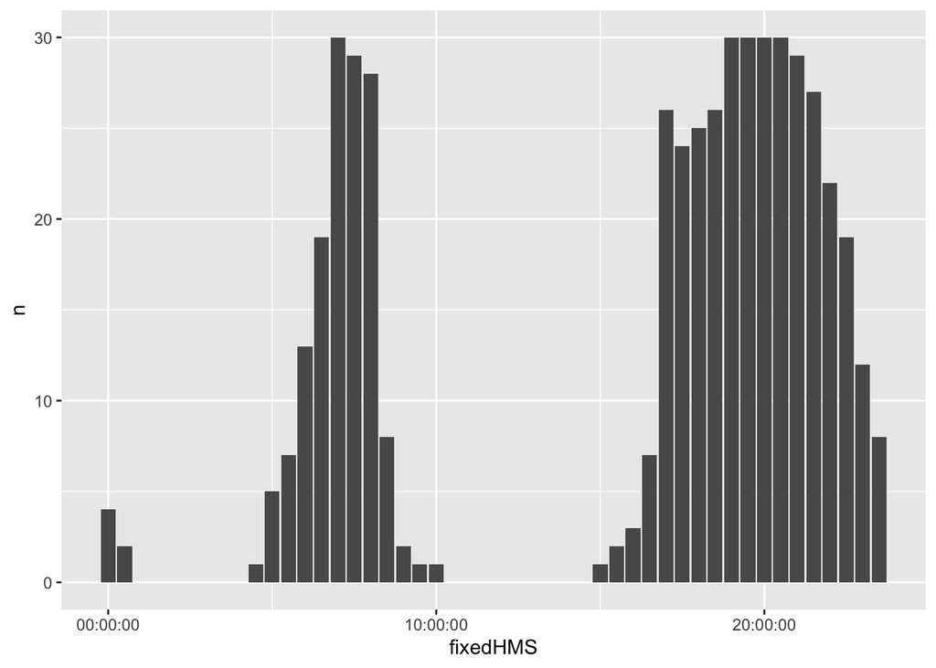

```r
# plot
ggplot2::ggplot(tableAll, aes(x = fixedHMS, y = n)) +
  geom_col()
```

## 3.2 Cooking

Here im am trying to look at anything related to preparing and eating a meal.

```r
# creating dataframe for all cooking
#Monday
tableCooking <- monday %>%
  select(fixedHMS, Activity) %>%
  filter(Activity != "Sleeping") %>%
  filter(Activity != "Rest") %>%
  filter(Activity != "Work") %>%
  filter(Activity %in% c("Cooking",
                         "Cooking (business)",
                         "Cooking (baby)",
                         "Cooking (lunch)",
                         "Food prep (business)",
                         "Lunch",
                         "Breakfast",
                         "Dinner",
                         "Light meal/snack")) %>%
  group_by(fixedHMS) %>%
  tally


tableCooking
```

```
## # A tibble: 17 x 2
##    fixedHMS     n
##    <time>   <int>
##  1 06:00        3
##  2 06:30        5
##  3 07:00        7
##  4 07:30        6
##  5 08:00        3
##  6 08:30        2
##  7 09:00        1
##  8 17:00        1
##  9 17:30        4
## 10 18:00        8
## 11 18:30        9
## 12 19:00       10
## 13 19:30       13
## 14 20:00        8
## 15 20:30        6
## 16 21:00        2
## 17 21:30        1
```

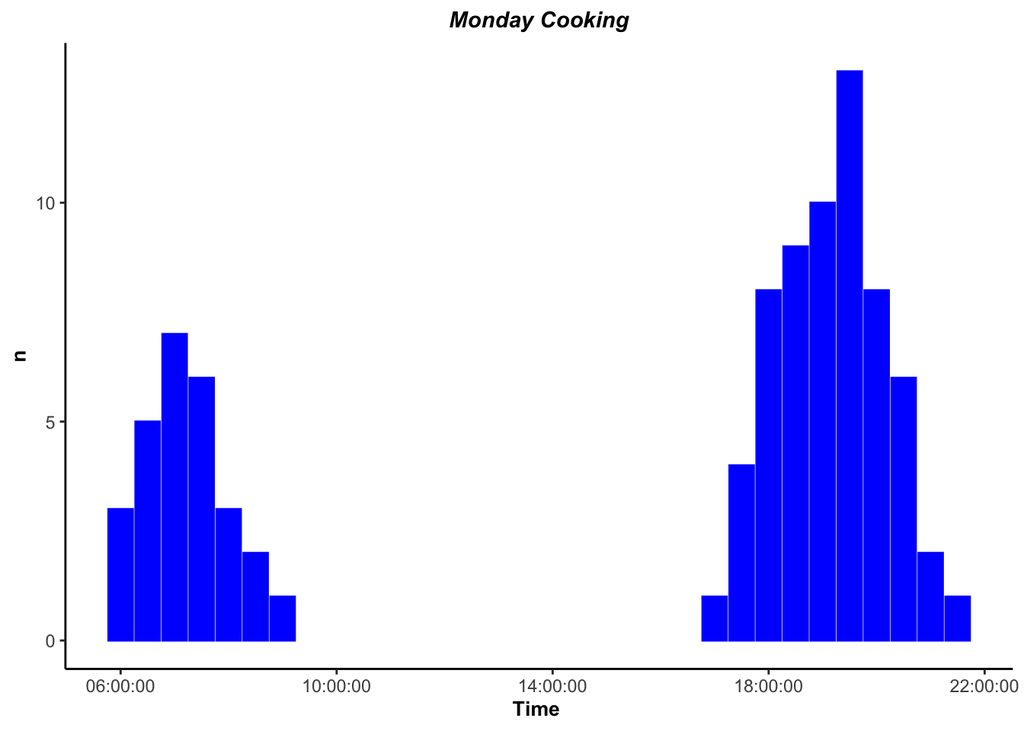

```r
MonCook <- ggplot(tableCooking, aes(x = fixedHMS, y = n)) + geom_bar(stat = "identity", position = "stack", color="blue", fill="blue") +
  ggtitle("Monday Cooking") +
  xlab("Time ") +
  ylab("n") + theme(plot.title = element_text(color="Black", size=11, face="bold.italic", hjust=0.5,lineheight=0.8),
        axis.title.x = element_text(color="black", size=10, face="bold"),
        axis.title.y = element_text(color="black", size=10, face="bold"),
        panel.background=element_rect(fill = "white"),
        panel.grid.minor = element_blank(),
        panel.grid.major = element_blank(),
        axis.line = element_line(colour = "black", size = 1) +
        scale_x_date(labels = date_format("%I:%M %p"))
)

MonCook
```

```r
#Tuesday

tableCookingTue <- tuesday %>%
  select(fixedHMS, Activity) %>%
  filter(Activity != "Sleeping") %>%
  filter(Activity != "Rest") %>%
  filter(Activity != "Work") %>%
  filter(Activity %in% c("Cooking",
                         "Cooking (business)",
                         "Cooking (baby)",
                         "Cooking (lunch)",
                         "Food prep (business)",
                         "Lunch",
                         "Breakfast",
                         "Dinner",
                         "Light meal/snack")) %>%
  group_by(fixedHMS) %>%
  tally


tableCookingTue
```

```
## # A tibble: 24 x 2
##    fixedHMS     n
##    <time>   <int>
##  1 05:00        1
##  2 05:30        1
##  3 06:00        2
##  4 06:30        2
##  5 07:00        1
##  6 07:30        1
##  7 08:00        1
##  8 09:00        1
##  9 12:30        1
## 10 13:00        1
## # … with 14 more rows
```

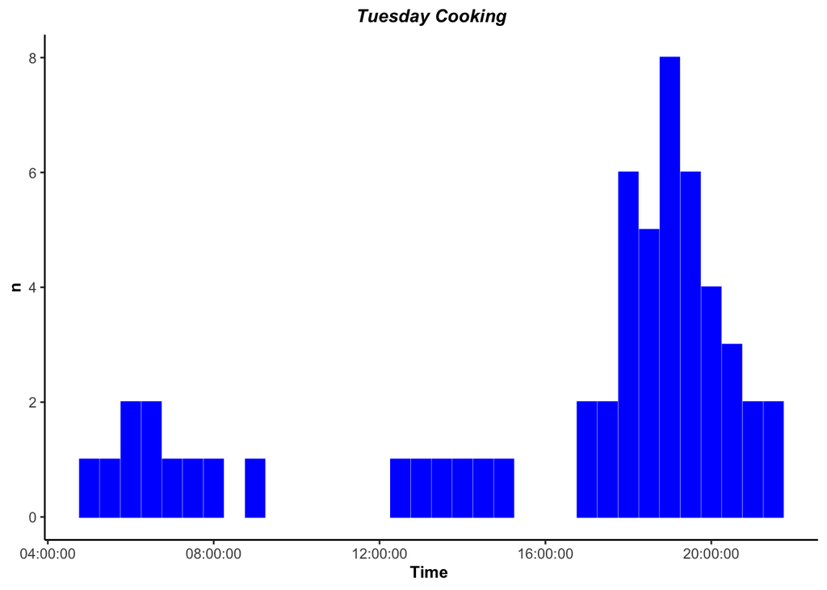

```r
TueCook <- ggplot(tableCookingTue, aes(x = fixedHMS, y = n)) + geom_bar(stat = "identity", position = "stack", color="blue", fill="blue") +
  ggtitle("Tuesday Cooking") +
  xlab("Time ") +
  ylab("n") + theme(plot.title = element_text(color="Black", size=11, face="bold.italic", hjust=0.5,lineheight=0.8),
        axis.title.x = element_text(color="black", size=10, face="bold"),
        axis.title.y = element_text(color="black", size=10, face="bold"),
        panel.background=element_rect(fill = "white"),
        panel.grid.minor = element_blank(),
        panel.grid.major = element_blank(),
        axis.line = element_line(colour = "black", size = 1) +
        scale_x_date(labels = date_format("%I:%M %p"))
)

TueCook
```

```r
#Wednesday

tableCookingWed <- wednesday %>%
  select(fixedHMS, Activity) %>%
  filter(Activity != "Sleeping") %>%
  filter(Activity != "Rest") %>%
  filter(Activity != "Work") %>%
  filter(Activity %in% c("Cooking",
                         "Cooking (business)",
                         "Cooking (baby)",
                         "Cooking (lunch)",
                         "Food prep (business)",
                         "Lunch",
                         "Breakfast",
                         "Dinner",
                         "Light meal/snack")) %>%
  group_by(fixedHMS) %>%
  tally


tableCookingWed
```

```
## # A tibble: 14 x 2
##    fixedHMS     n
##    <time>   <int>
##  1 06:00        2
##  2 06:30        2
##  3 07:00        5
##  4 07:30        6
##  5 08:00        1
##  6 17:30        1
##  7 18:00        3
##  8 18:30        4
##  9 19:00        8
## 10 19:30        8
## 11 20:00        4
## 12 20:30        4
## 13 21:00        2
## 14 21:30        1
```

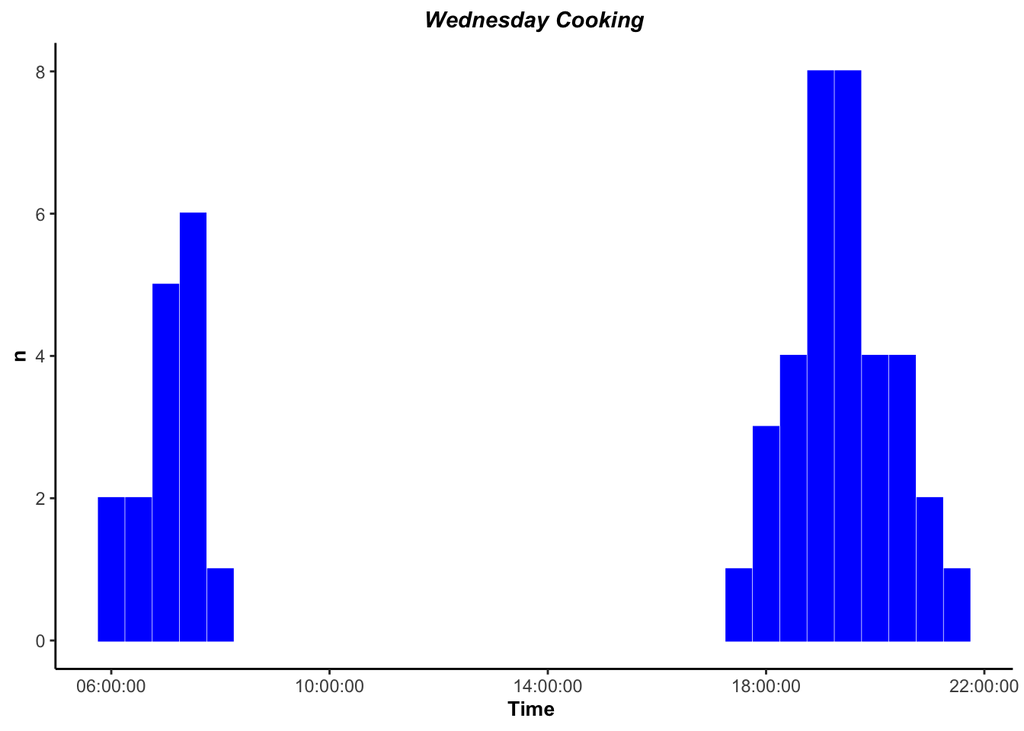

```r
WedCook <- ggplot(tableCookingWed, aes(x = fixedHMS, y = n)) + geom_bar(stat = "identity", position = "stack", color="blue", fill="blue") +
  ggtitle("Wednesday Cooking") +
  xlab("Time ") +
  ylab("n") + theme(plot.title = element_text(color="Black", size=11, face="bold.italic", hjust=0.5,lineheight=0.8),
        axis.title.x = element_text(color="black", size=10, face="bold"),
        axis.title.y = element_text(color="black", size=10, face="bold"),
        panel.background=element_rect(fill = "white"),
        panel.grid.minor = element_blank(),
        panel.grid.major = element_blank(),
        axis.line = element_line(colour = "black", size = 1) +
        scale_x_date(labels = date_format("%I:%M %p"))
)

WedCook
```

```r
#Thursday

tableCookingThu <- thursday %>%
  select(fixedHMS, Activity) %>%
  filter(Activity != "Sleeping") %>%
  filter(Activity != "Rest") %>%
  filter(Activity != "Work") %>%
  filter(Activity %in% c("Cooking",
                         "Cooking (business)",
                         "Cooking (baby)",
                         "Cooking (lunch)",
                         "Food prep (business)",
                         "Lunch",
                         "Breakfast",
                         "Dinner",
                         "Light meal/snack")) %>%
  group_by(fixedHMS) %>%
  tally


tableCookingThu
```

```
## # A tibble: 20 x 2
##    fixedHMS     n
##    <time>   <int>
##  1 06:30        1
##  2 07:30        1
##  3 08:00        2
##  4 08:30        1
##  5 09:00        1
##  6 09:30        1
##  7 10:00        1
##  8 14:30        1
##  9 17:30        2
## 10 18:00        1
## 11 18:30        3
## 12 19:00        2
## 13 19:30        1
## 14 20:00        2
## 15 20:30        1
## 16 21:00        1
## 17 21:30        1
## 18 22:00        1
## 19 22:30        1
## 20 23:00        1
```

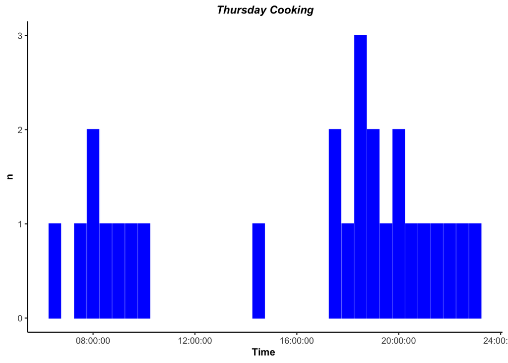

```r
ThuCook <- ggplot(tableCookingThu, aes(x = fixedHMS, y = n)) + geom_bar(stat = "identity", position = "stack", color="blue", fill="blue") +
  ggtitle("Thursday Cooking") +
  xlab("Time ") +
  ylab("n") + theme(plot.title = element_text(color="Black", size=11, face="bold.italic", hjust=0.5,lineheight=0.8),
        axis.title.x = element_text(color="black", size=10, face="bold"),
        axis.title.y = element_text(color="black", size=10, face="bold"),
        panel.background=element_rect(fill = "white"),
        panel.grid.minor = element_blank(),
        panel.grid.major = element_blank(),
        axis.line = element_line(colour = "black", size = 1) +
        scale_x_date(labels = date_format("%I:%M %p"))
)

ThuCook
```

```r
#Friday


tableCookingFri <- friday %>%
  select(fixedHMS, Activity) %>%
  filter(Activity != "Sleeping") %>%
  filter(Activity != "Rest") %>%
  filter(Activity != "Work") %>%
  filter(Activity %in% c("Cooking",
                         "Cooking (business)",
                         "Cooking (baby)",
                         "Cooking (lunch)",
                         "Food prep (business)",
                         "Lunch",
                         "Breakfast",
                         "Dinner",
                         "Light meal/snack")) %>%
  group_by(fixedHMS) %>%
  tally


tableCookingFri
```

```
## # A tibble: 20 x 2
##    fixedHMS     n
##    <time>   <int>
##  1 07:00        2
##  2 07:30        1
##  3 09:00        1
##  4 10:00        1
##  5 14:00        1
##  6 14:30        1
##  7 15:00        1
##  8 15:30        1
##  9 16:00        1
## 10 16:30        1
## 11 17:00        1
## 12 17:30        4
## 13 18:00        3
## 14 18:30        5
## 15 19:00        4
## 16 19:30        3
## 17 20:00        2
## 18 20:30        1
## 19 22:00        1
## 20 22:30        1
```

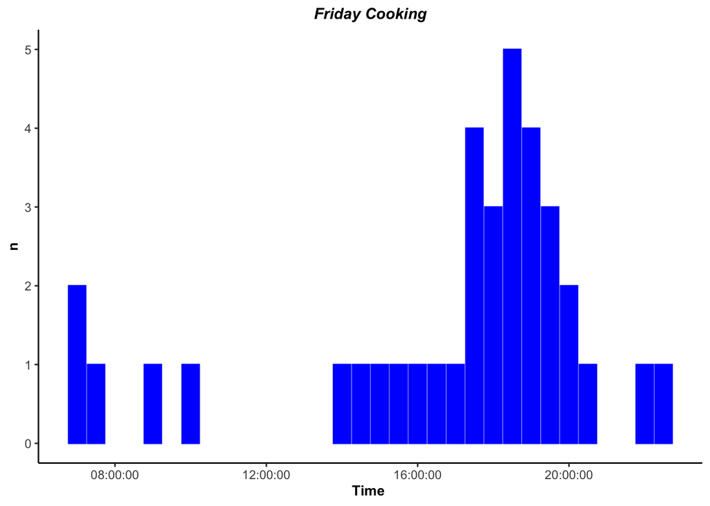

```r
FriCook <- ggplot(tableCookingFri, aes(x = fixedHMS, y = n)) + geom_bar(stat = "identity", position = "stack", color="blue", fill="blue") +
  ggtitle("Friday Cooking") +
  xlab("Time ") +
  ylab("n") + theme(plot.title = element_text(color="Black", size=11, face="bold.italic", hjust=0.5,lineheight=0.8),
        axis.title.x = element_text(color="black", size=10, face="bold"),
        axis.title.y = element_text(color="black", size=10, face="bold"),
        panel.background=element_rect(fill = "white"),
        panel.grid.minor = element_blank(),
        panel.grid.major = element_blank(),
        axis.line = element_line(colour = "black", size = 1) +
        scale_x_date(labels = date_format("%I:%M %p"))
)

FriCook
```

```r
#Weekdays

tableCookingWkd <- newdata %>%
  select(fixedHMS, Activity) %>%
  filter(Activity != "Sleeping") %>%
  filter(Activity != "Rest") %>%
  filter(Activity != "Work") %>%
  filter(Activity %in% c("Cooking",
                         "Cooking (business)",
                         "Cooking (baby)",
                         "Cooking (lunch)",
                         "Food prep (business)",
                         "Lunch",
                         "Breakfast",
                         "Dinner",
                         "Light meal/snack")) %>%
  group_by(fixedHMS) %>%
  tally


tableCookingWkd
```

```
## # A tibble: 33 x 2
##    fixedHMS     n
##    <time>   <int>
##  1 05:00        1
##  2 05:30        1
##  3 06:00        7
##  4 06:30       10
##  5 07:00       15
##  6 07:30       15
##  7 08:00        7
##  8 08:30        3
##  9 09:00        4
## 10 09:30        1
## # … with 23 more rows
```

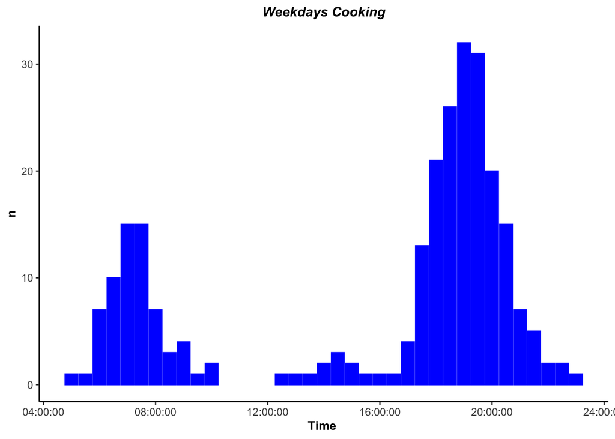

```r
WkdCook <- ggplot(tableCookingWkd, aes(x = fixedHMS, y = n)) + geom_bar(stat = "identity", position = "stack", color="blue", fill="blue") +
  ggtitle("Weekdays Cooking") +
  xlab("Time ") +
  ylab("n") + theme(plot.title = element_text(color="Black", size=11, face="bold.italic", hjust=0.5,lineheight=0.8),
        axis.title.x = element_text(color="black", size=10, face="bold"),
        axis.title.y = element_text(color="black", size=10, face="bold"),
        panel.background=element_rect(fill = "white"),
        panel.grid.minor = element_blank(),
        panel.grid.major = element_blank(),
        axis.line = element_line(colour = "black", size = 1) +
        scale_x_date(labels = date_format("%I:%M %p"))
)

WkdCook
```

## 3.3 Weekdays Tidy up

similar to the above but for tidy up/cleaning up

```r
# creating dataframe for all cleaning up

#Monday
mondayTidyup <- monday %>%
  select(fixedHMS, Activity) %>%
  filter(Activity != "Sleeping") %>%
  filter(Activity != "Rest") %>%
  filter(Activity != "Work") %>%
  filter(Activity %in% c("Tidy up",
                         "Laundry",
                         "Showering",
                         "Showering (kids)",
                         "Gardening",
                         "Getting dressed",
                         "Getting dressed (kids)",
                         "Prepare kids bag for school",
                         "Turning off applicances/Lights",
                         "Turning on appliances/lights",
                         "Ironing",
                         "Feeding animals")) %>%
  group_by(fixedHMS) %>%
  tally


mondayTidyup
```

```
## # A tibble: 21 x 2
##    fixedHMS     n
##    <time>   <int>
##  1 05:30        1
##  2 06:00        3
##  3 06:30        5
##  4 07:00        7
##  5 07:30       17
##  6 08:00        7
##  7 09:00        1
##  8 09:30        1
##  9 17:00        1
## 10 17:30        2
## # … with 11 more rows
```

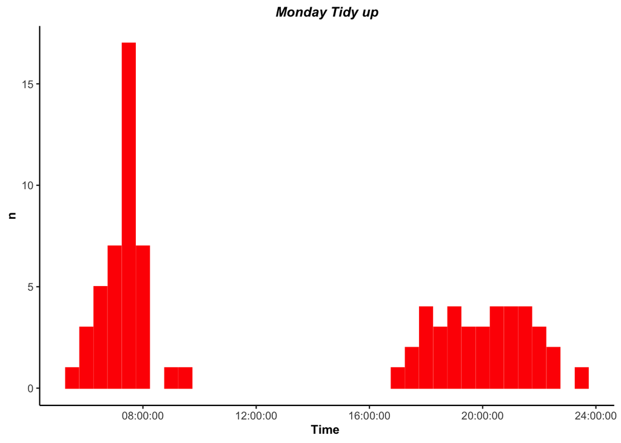

```r
MondayTidy <- ggplot(mondayTidyup, aes(x = fixedHMS, y = n)) + geom_bar(stat = "identity", position = "stack", color="red", fill="red") +
  ggtitle("Monday Tidy up") +
  xlab("Time ") +
  ylab("n") + theme(plot.title = element_text(color="Black", size=11, face="bold.italic", hjust=0.5,lineheight=0.8),
        axis.title.x = element_text(color="black", size=10, face="bold"),
        axis.title.y = element_text(color="black", size=10, face="bold"),
        panel.background=element_rect(fill = "white"),
        panel.grid.minor = element_blank(),
        panel.grid.major = element_blank(),
        axis.line = element_line(colour = "black", size = 1) +
        scale_x_date(labels = date_format("%I:%M %p"))
)

MondayTidy
```

```r
#Tuesday
tuesdayTidyup <- tuesday %>%
  select(fixedHMS, Activity) %>%
  filter(Activity != "Sleeping") %>%
  filter(Activity != "Rest") %>%
  filter(Activity != "Work") %>%
  filter(Activity %in% c("Tidy up",
                         "Laundry",
                         "Showering",
                         "Showering (kids)",
                         "Gardening",
                         "Getting dressed",
                         "Getting dressed (kids)",
                         "Prepare kids bag for school",
                         "Turning off applicances/Lights",
                         "Turning on appliances/lights",
                         "Ironing",
                         "Feeding animals")) %>%
  group_by(fixedHMS) %>%
  tally


tuesdayTidyup
```

```
## # A tibble: 24 x 2
##    fixedHMS     n
##    <time>   <int>
##  1 05:30        1
##  2 06:00        1
##  3 06:30        5
##  4 07:00        7
##  5 07:30       10
##  6 08:00        5
##  7 08:30        1
##  8 09:30        1
##  9 10:00        1
## 10 11:00        1
## # … with 14 more rows
```

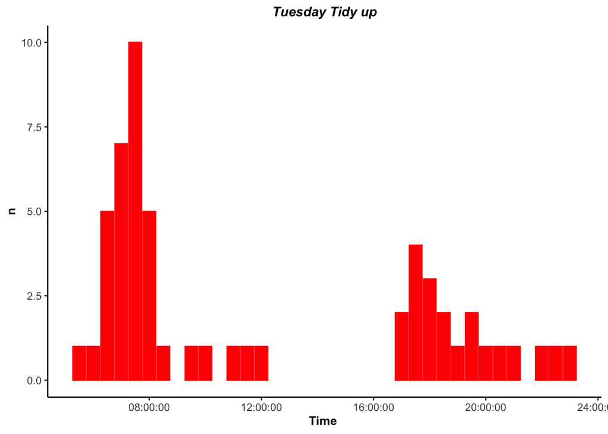

```r
TuesdayTidy <- ggplot(tuesdayTidyup, aes(x = fixedHMS, y = n)) + geom_bar(stat = "identity", position = "stack", color="red", fill="red") +
  ggtitle("Tuesday Tidy up") +
  xlab("Time ") +
  ylab("n") + theme(plot.title = element_text(color="Black", size=11, face="bold.italic", hjust=0.5,lineheight=0.8),
        axis.title.x = element_text(color="black", size=10, face="bold"),
        axis.title.y = element_text(color="black", size=10, face="bold"),
        panel.background=element_rect(fill = "white"),
        panel.grid.minor = element_blank(),
        panel.grid.major = element_blank(),
        axis.line = element_line(colour = "black", size = 1) +
        scale_x_date(labels = date_format("%I:%M %p"))
)

TuesdayTidy
```

```r
#Wednesday
wednesdayTidyup <- wednesday %>%
  select(fixedHMS, Activity) %>%
  filter(Activity != "Sleeping") %>%
  filter(Activity != "Rest") %>%
  filter(Activity != "Work") %>%
  filter(Activity %in% c("Tidy up",
                         "Laundry",
                         "Showering",
                         "Showering (kids)",
                         "Gardening",
                         "Getting dressed",
                         "Getting dressed (kids)",
                         "Prepare kids bag for school",
                         "Turning off applicances/Lights",
                         "Turning on appliances/lights",
                         "Ironing",
                         "Feeding animals")) %>%
  group_by(fixedHMS) %>%
  tally


wednesdayTidyup
```

```
## # A tibble: 27 x 2
##    fixedHMS     n
##    <time>   <int>
##  1 00:30        1
##  2 05:30        1
##  3 06:00        1
##  4 06:30        3
##  5 07:00        3
##  6 07:30        6
##  7 08:00        6
##  8 08:30        1
##  9 09:00        1
## 10 14:00        1
## # … with 17 more rows
```

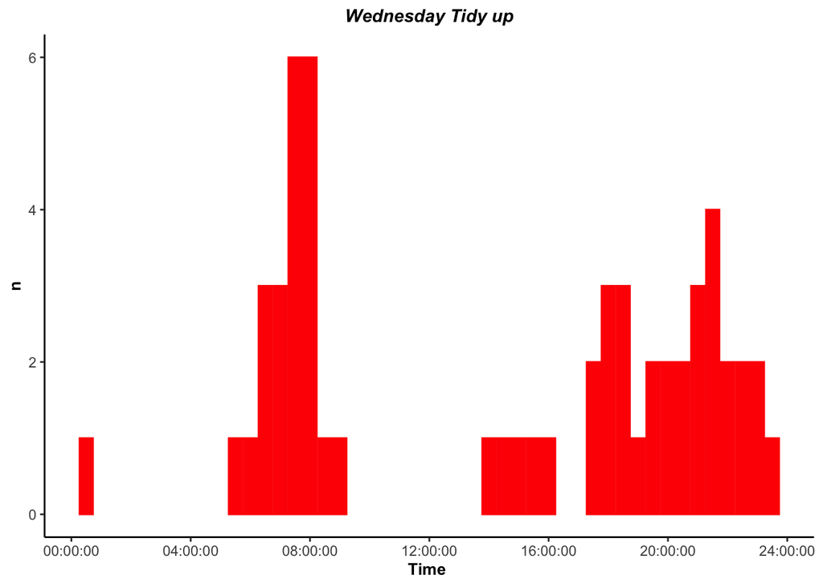

```r
WednesdayTidy <- ggplot(wednesdayTidyup, aes(x = fixedHMS, y = n)) + geom_bar(stat = "identity", position = "stack", color="red", fill="red") +
  ggtitle("Wednesday Tidy up") +
  xlab("Time ") +
  ylab("n") + theme(plot.title = element_text(color="Black", size=11, face="bold.italic", hjust=0.5,lineheight=0.8),
        axis.title.x = element_text(color="black", size=10, face="bold"),
        axis.title.y = element_text(color="black", size=10, face="bold"),
        panel.background=element_rect(fill = "white"),
        panel.grid.minor = element_blank(),
        panel.grid.major = element_blank(),
        axis.line = element_line(colour = "black", size = 1) +
        scale_x_date(labels = date_format("%I:%M %p"))
)

WednesdayTidy
```

```r
#Thursday
thursdayTidyup <- thursday %>%
  select(fixedHMS, Activity) %>%
  filter(Activity != "Sleeping") %>%
  filter(Activity != "Rest") %>%
  filter(Activity != "Work") %>%
  filter(Activity %in% c("Tidy up",
                         "Laundry",
                         "Showering",
                         "Showering (kids)",
                         "Gardening",
                         "Getting dressed",
                         "Getting dressed (kids)",
                         "Prepare kids bag for school",
                         "Turning off applicances/Lights",
                         "Turning on appliances/lights",
                         "Ironing",
                         "Feeding animals")) %>%
  group_by(fixedHMS) %>%
  tally


thursdayTidyup
```

```
## # A tibble: 18 x 2
##    fixedHMS     n
##    <time>   <int>
##  1 00:30        1
##  2 06:30        1
##  3 07:00        4
##  4 07:30        5
##  5 08:00        1
##  6 13:00        1
##  7 13:30        1
##  8 14:00        1
##  9 17:30        1
## 10 18:00        1
## 11 19:00        2
## 12 19:30        3
## 13 20:00        2
## 14 21:00        2
## 15 21:30        2
## 16 22:00        1
## 17 22:30        1
## 18 23:00        1
```

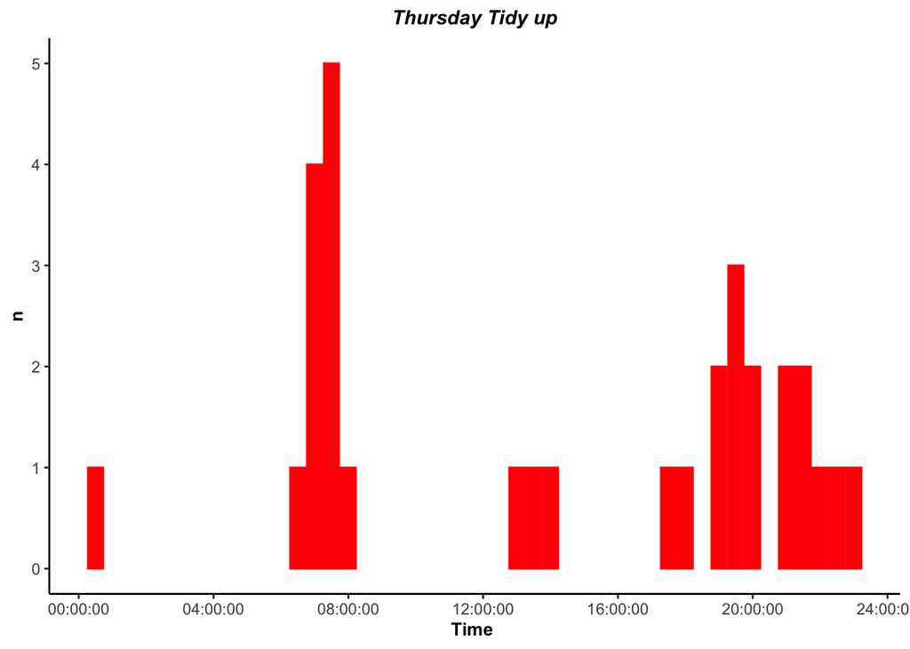

```r
ThursdayTidy <- ggplot(thursdayTidyup, aes(x = fixedHMS, y = n)) + geom_bar(stat = "identity", position = "stack", color="red", fill="red") +
  ggtitle("Thursday Tidy up") +
  xlab("Time ") +
  ylab("n") + theme(plot.title = element_text(color="Black", size=11, face="bold.italic", hjust=0.5,lineheight=0.8),
        axis.title.x = element_text(color="black", size=10, face="bold"),
        axis.title.y = element_text(color="black", size=10, face="bold"),
        panel.background=element_rect(fill = "white"),
        panel.grid.minor = element_blank(),
        panel.grid.major = element_blank(),
        axis.line = element_line(colour = "black", size = 1) +
        scale_x_date(labels = date_format("%I:%M %p"))
)

ThursdayTidy
```

```r
#Friday
fridayTidyup <- friday %>%
  select(fixedHMS, Activity) %>%
  filter(Activity != "Sleeping") %>%
  filter(Activity != "Rest") %>%
  filter(Activity != "Work") %>%
  filter(Activity %in% c("Tidy up",
                         "Laundry",
                         "Showering",
                         "Showering (kids)",
                         "Gardening",
                         "Getting dressed",
                         "Getting dressed (kids)",
                         "Prepare kids bag for school",
                         "Turning off applicances/Lights",
                         "Turning on appliances/lights",
                         "Ironing",
                         "Feeding animals")) %>%
  group_by(fixedHMS) %>%
  tally


fridayTidyup
```

```
## # A tibble: 19 x 2
##    fixedHMS     n
##    <time>   <int>
##  1 00:30        1
##  2 06:30        3
##  3 07:00        4
##  4 07:30        6
##  5 08:00        6
##  6 08:30        2
##  7 09:30        2
##  8 12:00        1
##  9 12:30        1
## 10 13:00        1
## 11 13:30        1
## 12 17:00        1
## 13 17:30        4
## 14 18:00        3
## 15 18:30        2
## 16 19:30        2
## 17 21:30        1
## 18 22:00        1
## 19 22:30        2
```

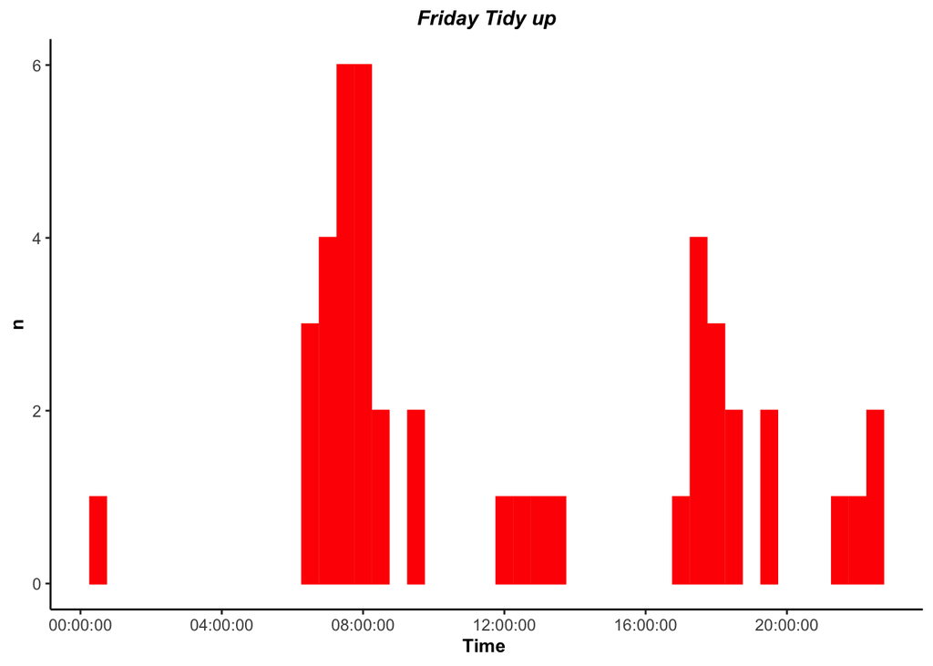

```r
FridayTidy <- ggplot(fridayTidyup, aes(x = fixedHMS, y = n)) + geom_bar(stat = "identity", position = "stack", color="red", fill="red") +
  ggtitle("Friday Tidy up") +
  xlab("Time ") +
  ylab("n") + theme(plot.title = element_text(color="Black", size=11, face="bold.italic", hjust=0.5,lineheight=0.8),
        axis.title.x = element_text(color="black", size=10, face="bold"),
        axis.title.y = element_text(color="black", size=10, face="bold"),
        panel.background=element_rect(fill = "white"),
        panel.grid.minor = element_blank(),
        panel.grid.major = element_blank(),
        axis.line = element_line(colour = "black", size = 1) +
        scale_x_date(labels = date_format("%I:%M %p"))
)

FridayTidy
```

```r
#Weekdays
weekdaysTidyup <- newdata %>%
  select(fixedHMS, Activity) %>%
  filter(Activity != "Sleeping") %>%
  filter(Activity != "Rest") %>%
  filter(Activity != "Work") %>%
  filter(Activity %in% c("Tidy up",
                         "Laundry",
                         "Showering",
                         "Showering (kids)",
                         "Gardening",
                         "Getting dressed",
                         "Getting dressed (kids)",
                         "Prepare kids bag for school",
                         "Turning off applicances/Lights",
                         "Turning on appliances/lights",
                         "Ironing",
                         "Feeding animals")) %>%
  group_by(fixedHMS) %>%
  tally


weekdaysTidyup
```

```
## # A tibble: 36 x 2
##    fixedHMS     n
##    <time>   <int>
##  1 00:30        3
##  2 05:30        3
##  3 06:00        5
##  4 06:30       17
##  5 07:00       25
##  6 07:30       44
##  7 08:00       25
##  8 08:30        4
##  9 09:00        2
## 10 09:30        4
## # … with 26 more rows
```

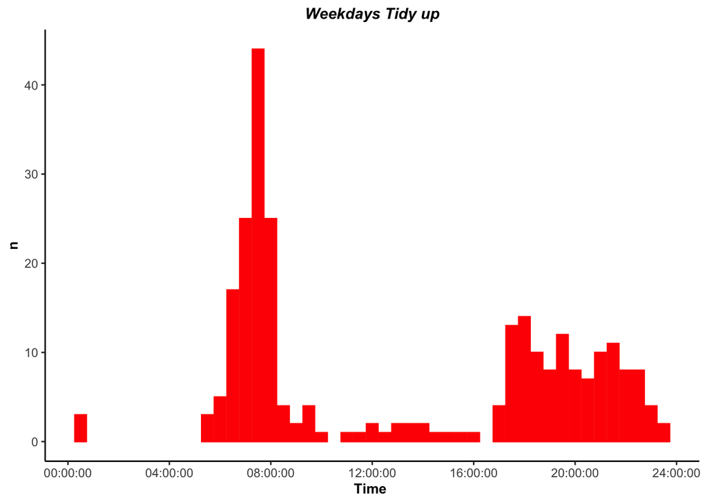

```r
WeekdaysTidy <- ggplot(weekdaysTidyup, aes(x = fixedHMS, y = n)) + geom_bar(stat = "identity", position = "stack", color="red", fill="red") +
  ggtitle("Weekdays Tidy up") +
  xlab("Time ") +
  ylab("n") + theme(plot.title = element_text(color="Black", size=11, face="bold.italic", hjust=0.5,lineheight=0.8),
        axis.title.x = element_text(color="black", size=10, face="bold"),
        axis.title.y = element_text(color="black", size=10, face="bold"),
        panel.background=element_rect(fill = "white"),
        panel.grid.minor = element_blank(),
        panel.grid.major = element_blank(),
        axis.line = element_line(colour = "black", size = 1) +
        scale_x_date(labels = date_format("%I:%M %p"))
)

WeekdaysTidy
```

## 3.4 Weekday Leisure

similar to the above but for leisure

```r
# creating dataframe for all leisure

#Monday
mondayleisure <- monday %>%
  select(fixedHMS, Activity) %>%
  filter(Activity != "Sleeping") %>%
  filter(Activity != "Rest") %>%
  filter(Activity != "Work") %>%
  filter(Activity %in% c("Babysitting",
                         "Charging mobile devices",
                         "Family devotion",
                         "Exercise (Jog, walk)",
                         "Family time (chatting, games etc)",
                         "Homework (kids)",
                         "Kids bedtime",
                         "Listen to music/radio",
                         "Mobile devices (movies)",
                         "Mobile devices (games)",
                         "Mobile devices (work)",
                         "Mobile devices (browsing, social media)",
                         "Scripture study",
                         "Studying",
                         "Reading",
                         "Watching movies (TV)")) %>%
  group_by(fixedHMS) %>%
  tally


mondayleisure
```

```
## # A tibble: 18 x 2
##    fixedHMS     n
##    <time>   <int>
##  1 00:00        1
##  2 00:30        1
##  3 05:30        2
##  4 06:30        1
##  5 07:00        1
##  6 17:30        1
##  7 18:00        2
##  8 18:30        6
##  9 19:00       10
## 10 19:30       10
## 11 20:00       15
## 12 20:30       15
## 13 21:00       18
## 14 21:30       19
## 15 22:00       15
## 16 22:30       12
## 17 23:00        8
## 18 23:30        4
```

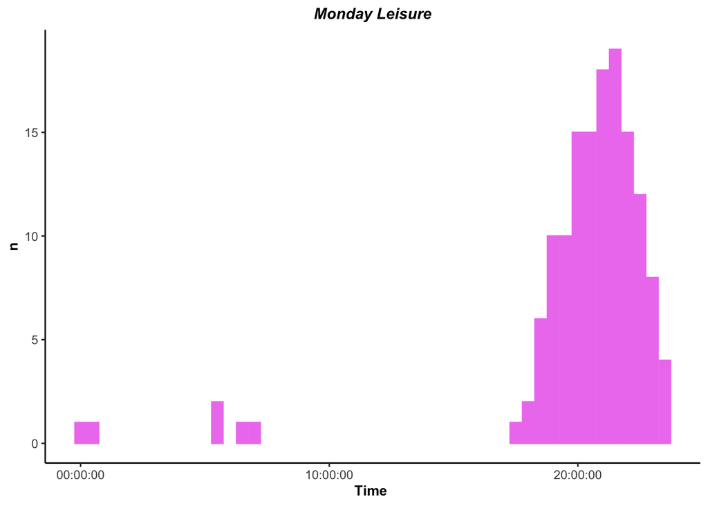

```r
Mondayleisure <- ggplot(mondayleisure, aes(x = fixedHMS, y = n)) + geom_bar(stat = "identity", position = "stack", color="violet", fill="violet") +
  ggtitle("Monday Leisure") +
  xlab("Time ") +
  ylab("n") + theme(plot.title = element_text(color="Black", size=11, face="bold.italic", hjust=0.5,lineheight=0.8),
        axis.title.x = element_text(color="black", size=10, face="bold"),
        axis.title.y = element_text(color="black", size=10, face="bold"),
        panel.background=element_rect(fill = "white"),
        panel.grid.minor = element_blank(),
        panel.grid.major = element_blank(),
        axis.line = element_line(colour = "black", size = 1) +
        scale_x_date(labels = date_format("%I:%M %p"))
)

Mondayleisure
```

```r
#Tuesday
tuesdayleisure <- tuesday %>%
  select(fixedHMS, Activity) %>%
  filter(Activity != "Sleeping") %>%
  filter(Activity != "Rest") %>%
  filter(Activity != "Work") %>%
  filter(Activity %in% c("Babysitting",
                         "Charging mobile devices",
                         "Family devotion",
                         "Exercise (Jog, walk)",
                         "Family time (chatting, games etc)",
                         "Homework (kids)",
                         "Kids bedtime",
                         "Listen to music/radio",
                         "Mobile devices (movies)",
                         "Mobile devices (games)",
                         "Mobile devices (work)",
                         "Mobile devices (browsing, social media)",
                         "Scripture study",
                         "Studying",
                         "Reading",
                         "Watching movies (TV)")) %>%
  group_by(fixedHMS) %>%
  tally


tuesdayleisure
```

```
## # A tibble: 18 x 2
##    fixedHMS     n
##    <time>   <int>
##  1 00:00        5
##  2 00:30        4
##  3 03:00        1
##  4 08:00        1
##  5 15:30        1
##  6 17:30        3
##  7 18:00        2
##  8 18:30        5
##  9 19:00        8
## 10 19:30        9
## 11 20:00        8
## 12 20:30        9
## 13 21:00       10
## 14 21:30       12
## 15 22:00       13
## 16 22:30       12
## 17 23:00        8
## 18 23:30        5
```

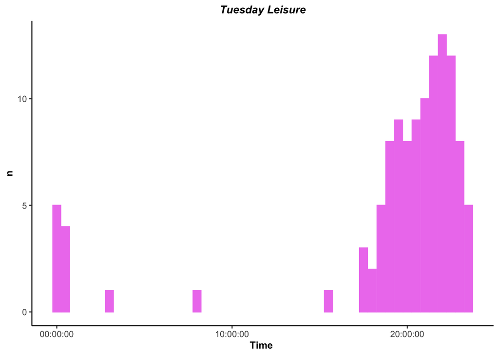

```r
Tuesdayleisure <- ggplot(tuesdayleisure, aes(x = fixedHMS, y = n)) + geom_bar(stat = "identity", position = "stack", color="violet", fill="violet") +
  ggtitle("Tuesday Leisure") +
  xlab("Time ") +
  ylab("n") + theme(plot.title = element_text(color="Black", size=11, face="bold.italic", hjust=0.5,lineheight=0.8),
        axis.title.x = element_text(color="black", size=10, face="bold"),
        axis.title.y = element_text(color="black", size=10, face="bold"),
        panel.background=element_rect(fill = "white"),
        panel.grid.minor = element_blank(),
        panel.grid.major = element_blank(),
        axis.line = element_line(colour = "black", size = 1) +
        scale_x_date(labels = date_format("%I:%M %p"))
)

Tuesdayleisure
```

```r
#Wednesday
wednesdayleisure <- wednesday %>%
  select(fixedHMS, Activity) %>%
  filter(Activity != "Sleeping") %>%
  filter(Activity != "Rest") %>%
  filter(Activity != "Work") %>%
  filter(Activity %in% c("Babysitting",
                         "Charging mobile devices",
                         "Family devotion",
                         "Exercise (Jog, walk)",
                         "Family time (chatting, games etc)",
                         "Homework (kids)",
                         "Kids bedtime",
                         "Listen to music/radio",
                         "Mobile devices (movies)",
                         "Mobile devices (games)",
                         "Mobile devices (work)",
                         "Mobile devices (browsing, social media)",
                         "Scripture study",
                         "Studying",
                         "Reading",
                         "Watching movies (TV)")) %>%
  group_by(fixedHMS) %>%
  tally


wednesdayleisure
```

```
## # A tibble: 19 x 2
##    fixedHMS     n
##    <time>   <int>
##  1 00:00        1
##  2 05:30        1
##  3 06:00        1
##  4 07:00        1
##  5 16:30        1
##  6 17:00        1
##  7 17:30        4
##  8 18:00        4
##  9 18:30        2
## 10 19:00        4
## 11 19:30        3
## 12 20:00        6
## 13 20:30        6
## 14 21:00        8
## 15 21:30        8
## 16 22:00        9
## 17 22:30        8
## 18 23:00        4
## 19 23:30        2
```

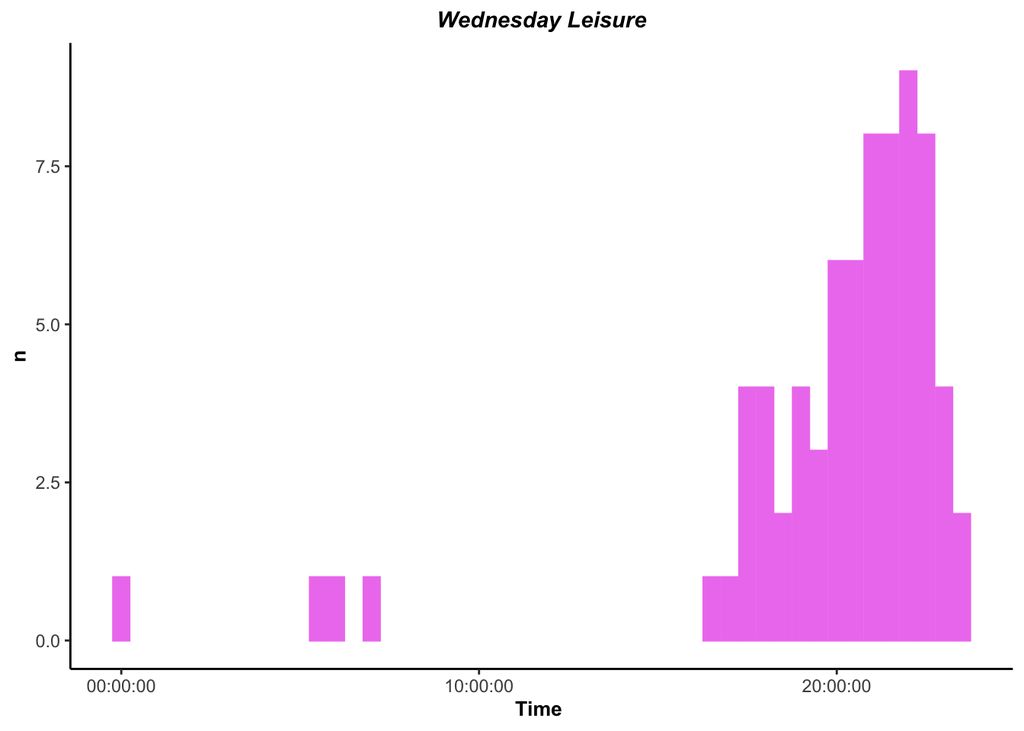

```r
Wednesdayleisure <- ggplot(wednesdayleisure, aes(x = fixedHMS, y = n)) + geom_bar(stat = "identity", position = "stack", color="violet", fill="violet") +
  ggtitle("Wednesday Leisure") +
  xlab("Time ") +
  ylab("n") + theme(plot.title = element_text(color="Black", size=11, face="bold.italic", hjust=0.5,lineheight=0.8),
        axis.title.x = element_text(color="black", size=10, face="bold"),
        axis.title.y = element_text(color="black", size=10, face="bold"),
        panel.background=element_rect(fill = "white"),
        panel.grid.minor = element_blank(),
        panel.grid.major = element_blank(),
        axis.line = element_line(colour = "black", size = 1) +
        scale_x_date(labels = date_format("%I:%M %p"))
)

Wednesdayleisure
```

```r
#Thursday
thursdayleisure <- thursday %>%
  select(fixedHMS, Activity) %>%
  filter(Activity != "Sleeping") %>%
  filter(Activity != "Rest") %>%
  filter(Activity != "Work") %>%
  filter(Activity %in% c("Babysitting",
                         "Charging mobile devices",
                         "Family devotion",
                         "Exercise (Jog, walk)",
                         "Family time (chatting, games etc)",
                         "Homework (kids)",
                         "Kids bedtime",
                         "Listen to music/radio",
                         "Mobile devices (movies)",
                         "Mobile devices (games)",
                         "Mobile devices (work)",
                         "Mobile devices (browsing, social media)",
                         "Scripture study",
                         "Studying",
                         "Reading",
                         "Watching movies (TV)")) %>%
  group_by(fixedHMS) %>%
  tally


thursdayleisure
```

```
## # A tibble: 15 x 2
##    fixedHMS     n
##    <time>   <int>
##  1 04:30        1
##  2 05:00        1
##  3 05:30        1
##  4 06:00        2
##  5 06:30        2
##  6 19:00        1
##  7 19:30        1
##  8 20:00        2
##  9 20:30        4
## 10 21:00        3
## 11 21:30        2
## 12 22:00        3
## 13 22:30        3
## 14 23:00        4
## 15 23:30        2
```

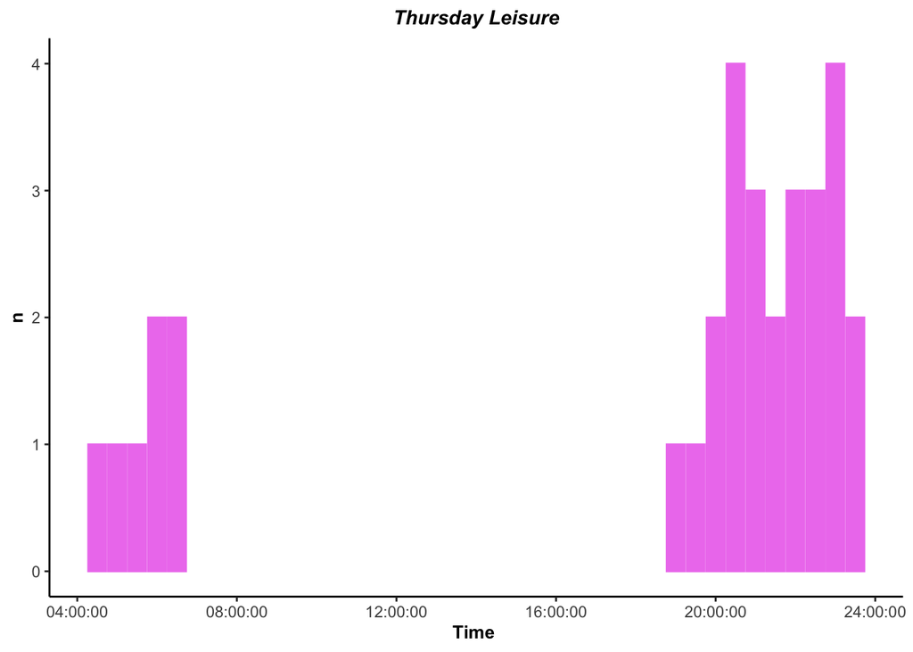

```r
Thursdayleisure <- ggplot(thursdayleisure, aes(x = fixedHMS, y = n)) + geom_bar(stat = "identity", position = "stack", color="violet", fill="violet") +
  ggtitle("Thursday Leisure") +
  xlab("Time ") +
  ylab("n") + theme(plot.title = element_text(color="Black", size=11, face="bold.italic", hjust=0.5,lineheight=0.8),
        axis.title.x = element_text(color="black", size=10, face="bold"),
        axis.title.y = element_text(color="black", size=10, face="bold"),
        panel.background=element_rect(fill = "white"),
        panel.grid.minor = element_blank(),
        panel.grid.major = element_blank(),
        axis.line = element_line(colour = "black", size = 1) +
        scale_x_date(labels = date_format("%I:%M %p"))
)

Thursdayleisure
```

```r
#Friday
fridayleisure <- friday %>%
  select(fixedHMS, Activity) %>%
  filter(Activity != "Sleeping") %>%
  filter(Activity != "Rest") %>%
  filter(Activity != "Work") %>%
  filter(Activity %in% c("Babysitting",
                         "Charging mobile devices",
                         "Family devotion",
                         "Exercise (Jog, walk)",
                         "Family time (chatting, games etc)",
                         "Homework (kids)",
                         "Kids bedtime",
                         "Listen to music/radio",
                         "Mobile devices (movies)",
                         "Mobile devices (games)",
                         "Mobile devices (work)",
                         "Mobile devices (browsing, social media)",
                         "Scripture study",
                         "Studying",
                         "Reading",
                         "Watching movies (TV)")) %>%
  group_by(fixedHMS) %>%
  tally


fridayleisure
```

```
## # A tibble: 36 x 2
##    fixedHMS     n
##    <time>   <int>
##  1 00:00        4
##  2 00:30        2
##  3 01:00        1
##  4 01:30        1
##  5 02:00        1
##  6 02:30        1
##  7 05:30        1
##  8 06:00        1
##  9 06:30        1
## 10 10:30        1
## # … with 26 more rows
```

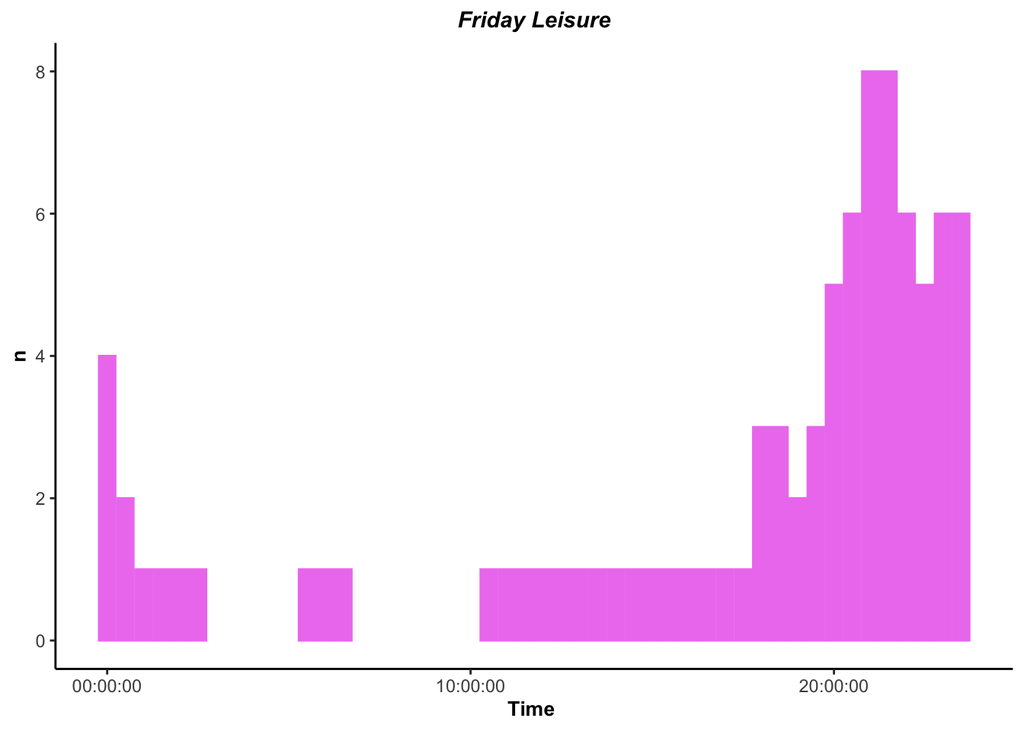

```r
Fridayleisure <- ggplot(fridayleisure, aes(x = fixedHMS, y = n)) + geom_bar(stat = "identity", position = "stack", color="violet", fill="violet") +
  ggtitle("Friday Leisure") +
  xlab("Time ") +
  ylab("n") + theme(plot.title = element_text(color="Black", size=11, face="bold.italic", hjust=0.5,lineheight=0.8),
        axis.title.x = element_text(color="black", size=10, face="bold"),
        axis.title.y = element_text(color="black", size=10, face="bold"),
        panel.background=element_rect(fill = "white"),
        panel.grid.minor = element_blank(),
        panel.grid.major = element_blank(),
        axis.line = element_line(colour = "black", size = 1) +
        scale_x_date(labels = date_format("%I:%M %p"))
)

Fridayleisure
```

```r
#Weekdays
weekdaysleisure <- newdata %>%
  select(fixedHMS, Activity) %>%
  filter(Activity != "Sleeping") %>%
  filter(Activity != "Rest") %>%
  filter(Activity != "Work") %>%
  filter(Activity %in% c("Babysitting",
                         "Charging mobile devices",
                         "Family devotion",
                         "Exercise (Jog, walk)",
                         "Family time (chatting, games etc)",
                         "Homework (kids)",
                         "Kids bedtime",
                         "Listen to music/radio",
                         "Mobile devices (movies)",
                         "Mobile devices (games)",
                         "Mobile devices (work)",
                         "Mobile devices (browsing, social media)",
                         "Scripture study",
                         "Studying",
                         "Reading",
                         "Watching movies (TV)")) %>%
  group_by(fixedHMS) %>%
  tally


weekdaysleisure
```

```
## # A tibble: 41 x 2
##    fixedHMS     n
##    <time>   <int>
##  1 00:00       11
##  2 00:30        7
##  3 01:00        1
##  4 01:30        1
##  5 02:00        1
##  6 02:30        1
##  7 03:00        1
##  8 04:30        1
##  9 05:00        1
## 10 05:30        5
## # … with 31 more rows
```

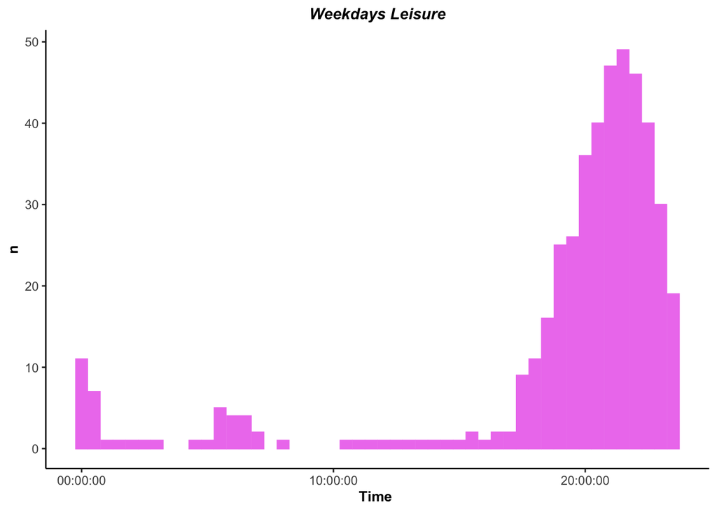

```r
Weekdayleisure <- ggplot(weekdaysleisure, aes(x = fixedHMS, y = n)) + geom_bar(stat = "identity", position = "stack", color="violet", fill="violet") +
  ggtitle("Weekdays Leisure") +
  xlab("Time ") +
  ylab("n") + theme(plot.title = element_text(color="Black", size=11, face="bold.italic", hjust=0.5,lineheight=0.8),
        axis.title.x = element_text(color="black", size=10, face="bold"),
        axis.title.y = element_text(color="black", size=10, face="bold"),
        panel.background=element_rect(fill = "white"),
        panel.grid.minor = element_blank(),
        panel.grid.major = element_blank(),
        axis.line = element_line(colour = "black", size = 1) +
        scale_x_date(labels = date_format("%I:%M %p"))
)

Weekdayleisure
```

## 3.5 Weekdays Away from home

similar to the above but for away from home

```r
# creating dataframe for Away from Home

#Monday
mondayAway <- monday %>%
  select(fixedHMS, Activity) %>%
  filter(Activity != "Sleeping") %>%
  filter(Activity != "Rest") %>%
  filter(Activity %in% c("Farm",
                         "Relatives",
                         "Work",
                         "Kava",
                         "Church",
                         "Church (social activities)",
                         "Church (choir practice)",
                         "Exercise (Jog, walk)",
                         "Gym",
                         "Sports",
                         "School",
                         "Going out"))%>%
  group_by(fixedHMS) %>%
  tally


mondayAway
```

```
## # A tibble: 31 x 2
##    fixedHMS     n
##    <time>   <int>
##  1 05:30        2
##  2 06:00        2
##  3 06:30        3
##  4 07:00        1
##  5 07:30        2
##  6 08:00        4
##  7 08:30       24
##  8 09:00       30
##  9 09:30       31
## 10 10:00       31
## # … with 21 more rows
```

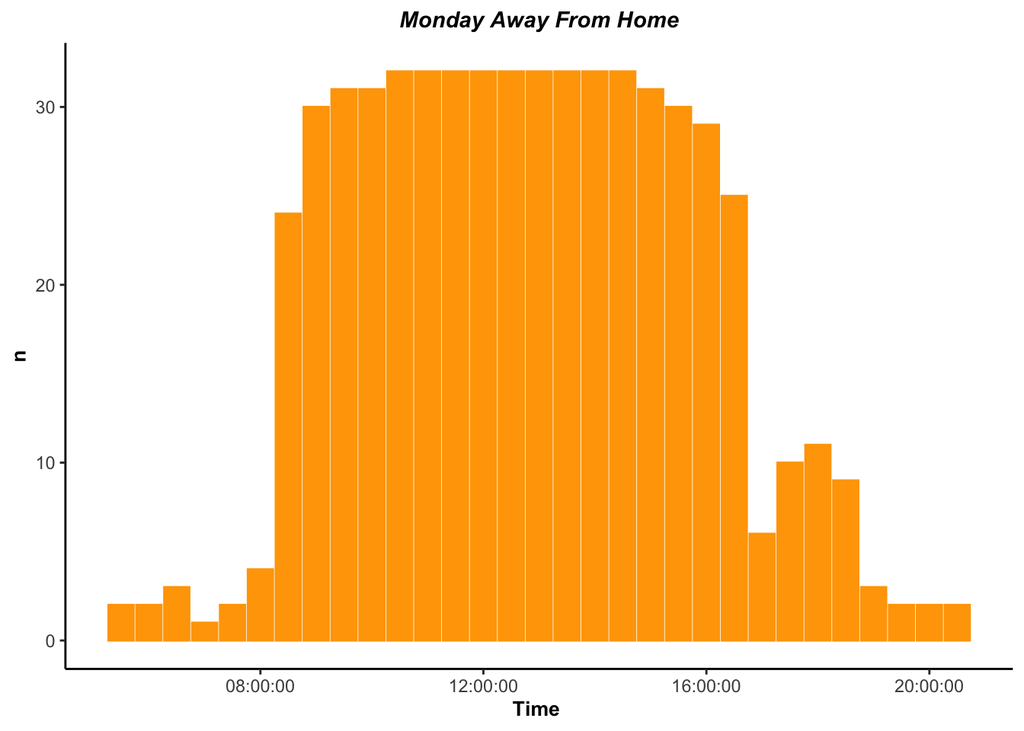

```r
MondayAwayHome <- ggplot(mondayAway, aes(x = fixedHMS, y = n)) + geom_bar(stat = "identity", position = "stack", color="orange", fill="orange") +
  ggtitle("Monday Away From Home") +
  xlab("Time ") +
  ylab("n") + theme(plot.title = element_text(color="Black", size=11, face="bold.italic", hjust=0.5,lineheight=0.8),
        axis.title.x = element_text(color="black", size=10, face="bold"),
        axis.title.y = element_text(color="black", size=10, face="bold"),
        panel.background=element_rect(fill = "white"),
        panel.grid.minor = element_blank(),
        panel.grid.major = element_blank(),
        axis.line = element_line(colour = "black", size = 1) +
        scale_x_date(labels = date_format("%I:%M %p"))
)

MondayAwayHome
```

```r
#Tuesday
tuesdayAway <- tuesday %>%
  select(fixedHMS, Activity) %>%
  filter(Activity != "Sleeping") %>%
  filter(Activity != "Rest") %>%
  filter(Activity %in% c("Farm",
                         "Relatives",
                         "Work",
                         "Kava",
                         "Church",
                         "Church (social activities)",
                         "Church (choir practice)",
                         "Exercise (Jog, walk)",
                         "Gym",
                         "Sports",
                         "School",
                         "Going out"))%>%
  group_by(fixedHMS) %>%
  tally


tuesdayAway
```

```
## # A tibble: 40 x 2
##    fixedHMS     n
##    <time>   <int>
##  1 00:00        1
##  2 00:30        1
##  3 01:00        1
##  4 01:30        1
##  5 02:00        1
##  6 02:30        1
##  7 07:00        1
##  8 07:30        1
##  9 08:00        3
## 10 08:30       12
## # … with 30 more rows
```

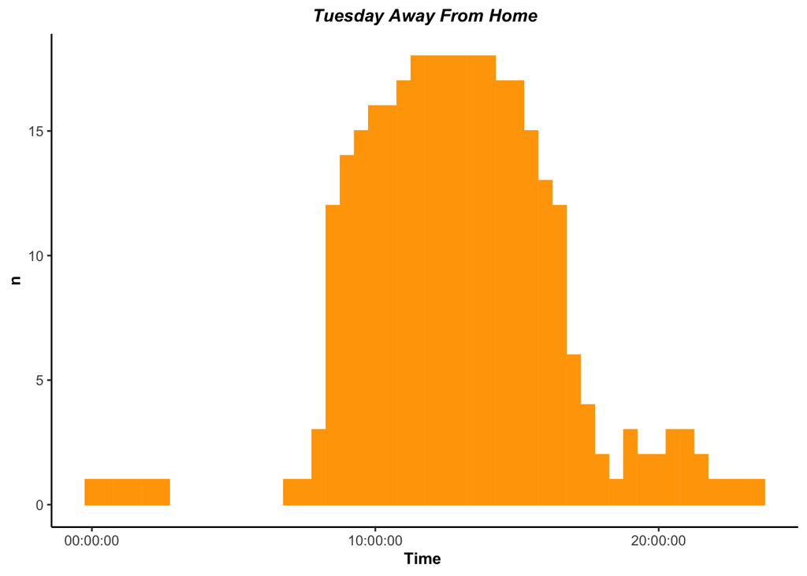

```r
TuesdayAwayHome <- ggplot(tuesdayAway, aes(x = fixedHMS, y = n)) + geom_bar(stat = "identity", position = "stack", color="orange", fill="orange") +
  ggtitle("Tuesday Away From Home") +
  xlab("Time ") +
  ylab("n") + theme(plot.title = element_text(color="Black", size=11, face="bold.italic", hjust=0.5,lineheight=0.8),
        axis.title.x = element_text(color="black", size=10, face="bold"),
        axis.title.y = element_text(color="black", size=10, face="bold"),
        panel.background=element_rect(fill = "white"),
        panel.grid.minor = element_blank(),
        panel.grid.major = element_blank(),
        axis.line = element_line(colour = "black", size = 1) +
        scale_x_date(labels = date_format("%I:%M %p"))
)

TuesdayAwayHome
```

```r
#Wednesday
wednesdayAway <- wednesday %>%
  select(fixedHMS, Activity) %>%
  filter(Activity != "Sleeping") %>%
  filter(Activity != "Rest") %>%
  filter(Activity %in% c("Farm",
                         "Relatives",
                         "Work",
                         "Kava",
                         "Church",
                         "Church (social activities)",
                         "Church (choir practice)",
                         "Exercise (Jog, walk)",
                         "Gym",
                         "Sports",
                         "School",
                         "Going out"))%>%
  group_by(fixedHMS) %>%
  tally


wednesdayAway
```

```
## # A tibble: 31 x 2
##    fixedHMS     n
##    <time>   <int>
##  1 05:30        2
##  2 06:00        2
##  3 06:30        1
##  4 07:00        1
##  5 08:00        1
##  6 08:30        9
##  7 09:00       14
##  8 09:30       14
##  9 10:00       14
## 10 10:30       14
## # … with 21 more rows
```

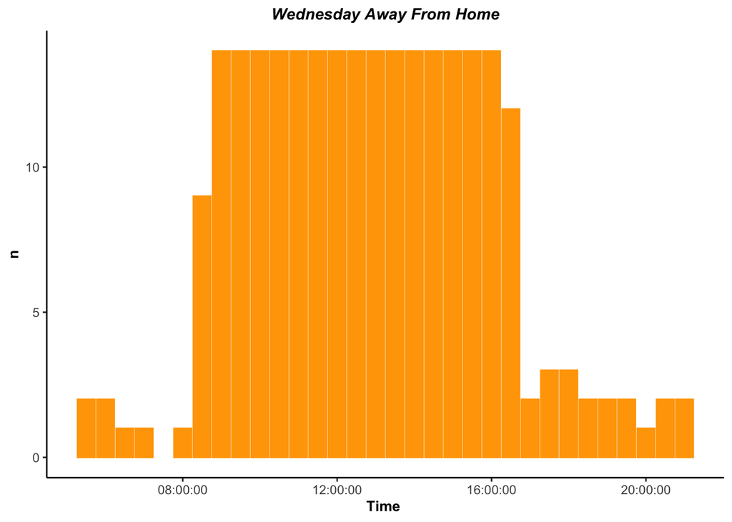

```r
WednesdayAwayHome <- ggplot(wednesdayAway, aes(x = fixedHMS, y = n)) + geom_bar(stat = "identity", position = "stack", color="orange", fill="orange") +
  ggtitle("Wednesday Away From Home") +
  xlab("Time ") +
  ylab("n") + theme(plot.title = element_text(color="Black", size=11, face="bold.italic", hjust=0.5,lineheight=0.8),
        axis.title.x = element_text(color="black", size=10, face="bold"),
        axis.title.y = element_text(color="black", size=10, face="bold"),
        panel.background=element_rect(fill = "white"),
        panel.grid.minor = element_blank(),
        panel.grid.major = element_blank(),
        axis.line = element_line(colour = "black", size = 1) +
        scale_x_date(labels = date_format("%I:%M %p"))
)

WednesdayAwayHome
```

```r
#Thursday
thursdayAway <- thursday %>%
  select(fixedHMS, Activity) %>%
  filter(Activity != "Sleeping") %>%
  filter(Activity != "Rest") %>%
  filter(Activity %in% c("Farm",
                         "Relatives",
                         "Work",
                         "Kava",
                         "Church",
                         "Church (social activities)",
                         "Church (choir practice)",
                         "Exercise (Jog, walk)",
                         "Gym",
                         "Sports",
                         "School",
                         "Going out"))%>%
  group_by(fixedHMS) %>%
  tally


thursdayAway
```

```
## # A tibble: 33 x 2
##    fixedHMS     n
##    <time>   <int>
##  1 05:30        1
##  2 06:00        1
##  3 06:30        1
##  4 07:30        1
##  5 08:00        1
##  6 08:30        6
##  7 09:00        7
##  8 09:30        7
##  9 10:00        7
## 10 10:30        7
## # … with 23 more rows
```

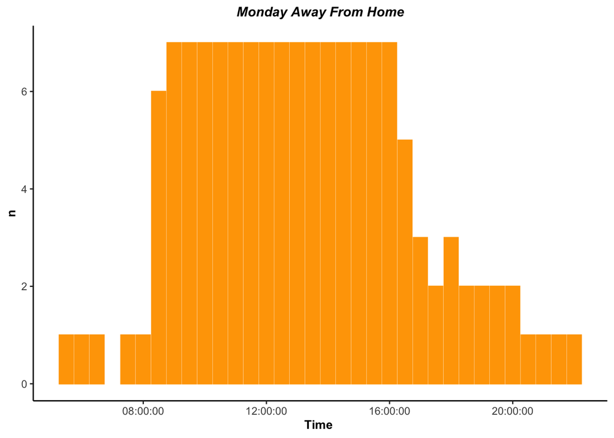

```r
ThursdayAwayHome <- ggplot(thursdayAway, aes(x = fixedHMS, y = n)) + geom_bar(stat = "identity", position = "stack", color="orange", fill="orange") +
  ggtitle("Monday Away From Home") +
  xlab("Time ") +
  ylab("n") + theme(plot.title = element_text(color="Black", size=11, face="bold.italic", hjust=0.5,lineheight=0.8),
        axis.title.x = element_text(color="black", size=10, face="bold"),
        axis.title.y = element_text(color="black", size=10, face="bold"),
        panel.background=element_rect(fill = "white"),
        panel.grid.minor = element_blank(),
        panel.grid.major = element_blank(),
        axis.line = element_line(colour = "black", size = 1) +
        scale_x_date(labels = date_format("%I:%M %p"))
)

ThursdayAwayHome
```

```r
#Friday
fridayAway <- friday %>%
  select(fixedHMS, Activity) %>%
  filter(Activity != "Sleeping") %>%
  filter(Activity != "Rest") %>%
  filter(Activity %in% c("Farm",
                         "Relatives",
                         "Work",
                         "Kava",
                         "Church",
                         "Church (social activities)",
                         "Church (choir practice)",
                         "Exercise (Jog, walk)",
                         "Gym",
                         "Sports",
                         "School",
                         "Going out"))%>%
  group_by(fixedHMS) %>%
  tally


fridayAway
```

```
## # A tibble: 32 x 2
##    fixedHMS     n
##    <time>   <int>
##  1 06:00        1
##  2 07:00        1
##  3 07:30        1
##  4 08:00        3
##  5 08:30        8
##  6 09:00       11
##  7 09:30       13
##  8 10:00       13
##  9 10:30       14
## 10 11:00       14
## # … with 22 more rows
```

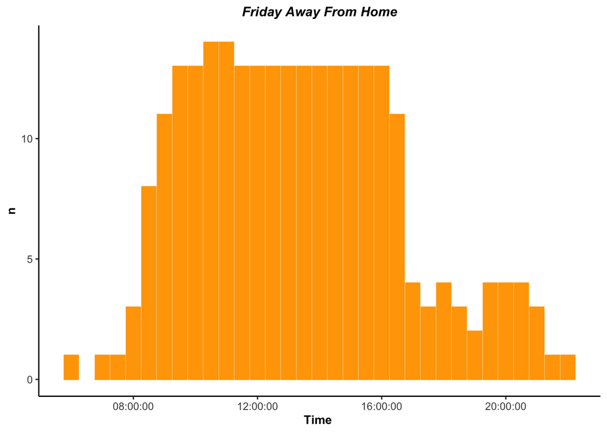

```r
FridayAwayHome <- ggplot(fridayAway, aes(x = fixedHMS, y = n)) + geom_bar(stat = "identity", position = "stack", color="orange", fill="orange") +
  ggtitle("Friday Away From Home") +
  xlab("Time ") +
  ylab("n") + theme(plot.title = element_text(color="Black", size=11, face="bold.italic", hjust=0.5,lineheight=0.8),
        axis.title.x = element_text(color="black", size=10, face="bold"),
        axis.title.y = element_text(color="black", size=10, face="bold"),
        panel.background=element_rect(fill = "white"),
        panel.grid.minor = element_blank(),
        panel.grid.major = element_blank(),
        axis.line = element_line(colour = "black", size = 1) +
        scale_x_date(labels = date_format("%I:%M %p"))
)

FridayAwayHome
```

```r
#Weekday
weekdayAway <- newdata %>%
  select(fixedHMS, Activity) %>%
  filter(Activity != "Sleeping") %>%
  filter(Activity != "Rest") %>%
  filter(Activity %in% c("Farm",
                         "Relatives",
                         "Work",
                         "Kava",
                         "Church",
                         "Church (social activities)",
                         "Church (choir practice)",
                         "Exercise (Jog, walk)",
                         "Gym",
                         "Sports",
                         "School",
                         "Going out"))%>%
  group_by(fixedHMS) %>%
  tally


weekdayAway
```

```
## # A tibble: 43 x 2
##    fixedHMS     n
##    <time>   <int>
##  1 00:00        1
##  2 00:30        1
##  3 01:00        1
##  4 01:30        1
##  5 02:00        1
##  6 02:30        1
##  7 05:30        5
##  8 06:00        6
##  9 06:30        5
## 10 07:00        4
## # … with 33 more rows
```

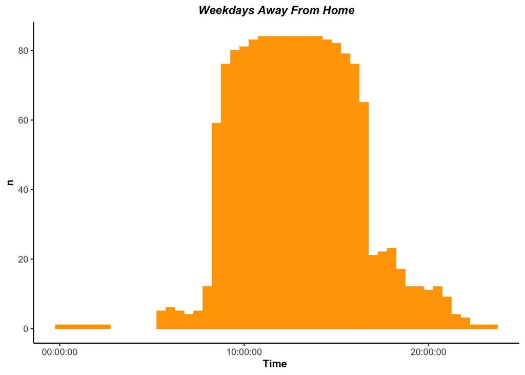

```r
WeekdaysAwayHome <- ggplot(weekdayAway, aes(x = fixedHMS, y = n)) + geom_bar(stat = "identity", position = "stack", color="orange", fill="orange") +
  ggtitle("Weekdays Away From Home") +
  xlab("Time ") +
  ylab("n") + theme(plot.title = element_text(color="Black", size=11, face="bold.italic", hjust=0.5,lineheight=0.8),
        axis.title.x = element_text(color="black", size=10, face="bold"),
        axis.title.y = element_text(color="black", size=10, face="bold"),
        panel.background=element_rect(fill = "white"),
        panel.grid.minor = element_blank(),
        panel.grid.major = element_blank(),
        axis.line = element_line(colour = "black", size = 1) +
        scale_x_date(labels = date_format("%I:%M %p"))
)

WeekdaysAwayHome
```

## 3.6 Monday Transport

similar to the above but for transportation

> BA: table breaks for some reason?

```r
# creating dataframe for transportation

# Monday
mondayTransport <- monday %>%
  select(fixedHMS, Activity) %>%
  filter(Activity != "Sleeping") %>%
  filter(Activity != "Rest") %>%
  filter(Activity != "Work") %>%
  filter(Activity %in% c("Driving (church)",
                         "Driving (drop kids)",
                         "Driving (drop relatives)",
                         "Driving (farm)",
                         "Driving (free time)",
                         "Driving (gym)",
                         "Driving (home)",
                         "Driving (Kava)",
                         "Driving (order delivery)",
                         "Driving (pick up kids)",
                         "Driving (visiting relatives)",
                         "Driving (work)",
                         "Public transport (home)",
                         "Public transport (work)",
                         "Public transport (school)",
                         "Walking (home)",
                         "Walking (work)",
                         "Walking (Kava)")) %>%
  group_by(fixedHMS) %>%
  tally


mondayTransport
```

```
## # A tibble: 21 x 2
##    fixedHMS     n
##    <time>   <int>
##  1 05:00        1
##  2 07:00        2
##  3 07:30        6
##  4 08:00       17
##  5 08:30        6
##  6 10:00        1
##  7 15:00        1
##  8 15:30        2
##  9 16:00        3
## 10 16:30        5
## # … with 11 more rows
```

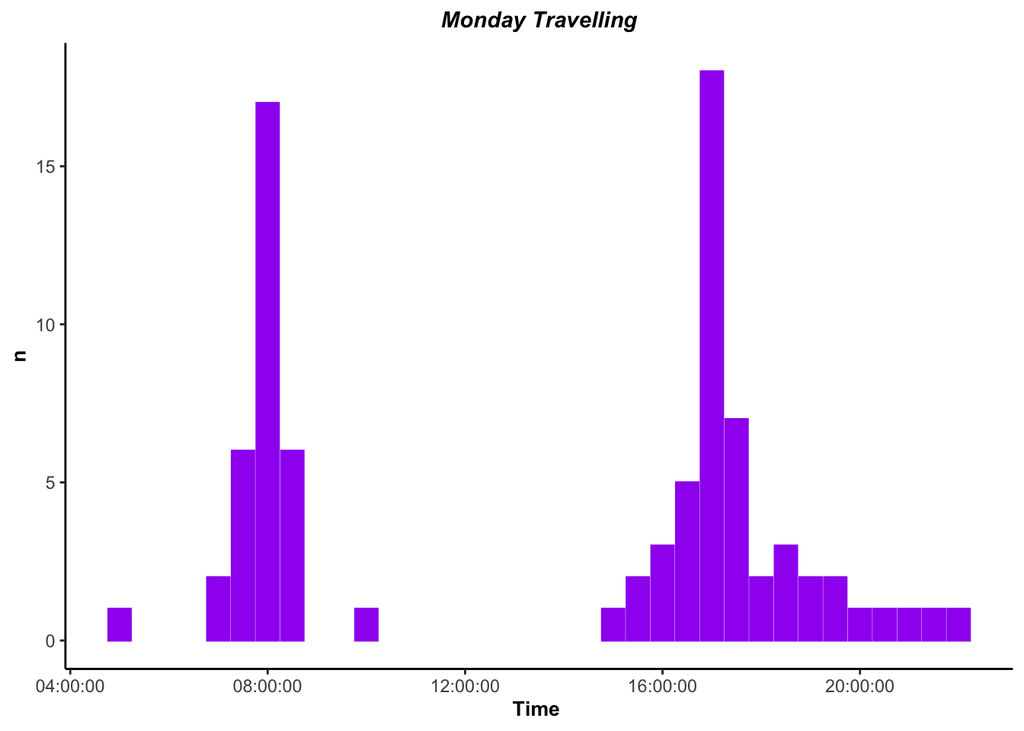

```r
#ploting Bar graph

MondayTransport <- ggplot(mondayTransport, aes(x = fixedHMS, y = n)) + geom_bar(stat = "identity", position = "stack", color="purple", fill="purple") +
  ggtitle("Monday Travelling") +
  xlab("Time ") +
  ylab("n") + theme(plot.title = element_text(color="Black", size=11, face="bold.italic", hjust=0.5,lineheight=0.8),
        axis.title.x = element_text(color="black", size=10, face="bold"),
        axis.title.y = element_text(color="black", size=10, face="bold"),
        panel.background=element_rect(fill = "white"),
        panel.grid.minor = element_blank(),
        panel.grid.major = element_blank(),
        axis.line = element_line(colour = "black", size = 1) +
        scale_x_date(labels = date_format("%I:%M %p"))
)

MondayTransport
```

```r
# Tuesday
tuesdayTransport <- tuesday %>%
  select(fixedHMS, Activity) %>%
  filter(Activity != "Sleeping") %>%
  filter(Activity != "Rest") %>%
  filter(Activity != "Work") %>%
  filter(Activity %in% c("Driving (church)",
                         "Driving (drop kids)",
                         "Driving (drop relatives)",
                         "Driving (farm)",
                         "Driving (free time)",
                         "Driving (gym)",
                         "Driving (home)",
                         "Driving (Kava)",
                         "Driving (order delivery)",
                         "Driving (pick up kids)",
                         "Driving (visiting relatives)",
                         "Driving (work)",
                         "Public transport (home)",
                         "Public transport (work)",
                         "Public transport (school)",
                         "Walking (home)",
                         "Walking (work)",
                         "Walking (Kava)")) %>%
  group_by(fixedHMS) %>%
  tally


tuesdayTransport
```

```
## # A tibble: 21 x 2
##    fixedHMS     n
##    <time>   <int>
##  1 06:30        1
##  2 07:00        1
##  3 07:30        3
##  4 08:00        9
##  5 08:30        5
##  6 09:00        3
##  7 09:30        3
##  8 10:00        2
##  9 10:30        1
## 10 11:00        1
## # … with 11 more rows
```

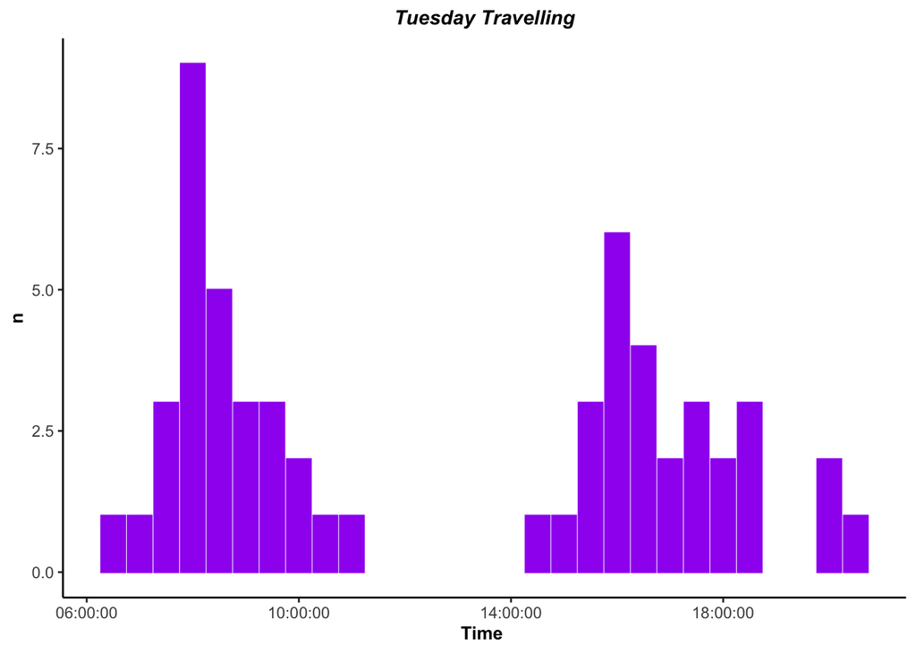

```r
#ploting Bar graph

TuesdayTransport <- ggplot(tuesdayTransport, aes(x = fixedHMS, y = n)) + geom_bar(stat = "identity", position = "stack", color="purple", fill="purple") +
  ggtitle("Tuesday Travelling") +
  xlab("Time ") +
  ylab("n") + theme(plot.title = element_text(color="Black", size=11, face="bold.italic", hjust=0.5,lineheight=0.8),
        axis.title.x = element_text(color="black", size=10, face="bold"),
        axis.title.y = element_text(color="black", size=10, face="bold"),
        panel.background=element_rect(fill = "white"),
        panel.grid.minor = element_blank(),
        panel.grid.major = element_blank(),
        axis.line = element_line(colour = "black", size = 1) +
        scale_x_date(labels = date_format("%I:%M %p"))
)

TuesdayTransport
```

```r
# Wednesday
wednesdayTransport <- wednesday %>%
  select(fixedHMS, Activity) %>%
  filter(Activity != "Sleeping") %>%
  filter(Activity != "Rest") %>%
  filter(Activity != "Work") %>%
  filter(Activity %in% c("Driving (church)",
                         "Driving (drop kids)",
                         "Driving (drop relatives)",
                         "Driving (farm)",
                         "Driving (free time)",
                         "Driving (gym)",
                         "Driving (home)",
                         "Driving (Kava)",
                         "Driving (order delivery)",
                         "Driving (pick up kids)",
                         "Driving (visiting relatives)",
                         "Driving (work)",
                         "Public transport (home)",
                         "Public transport (work)",
                         "Public transport (school)",
                         "Walking (home)",
                         "Walking (work)",
                         "Walking (Kava)")) %>%
  group_by(fixedHMS) %>%
  tally


wednesdayTransport
```

```
## # A tibble: 19 x 2
##    fixedHMS     n
##    <time>   <int>
##  1 05:00        1
##  2 05:30        1
##  3 07:30        1
##  4 08:00        7
##  5 08:30        5
##  6 09:30        1
##  7 10:00        1
##  8 10:30        1
##  9 11:00        1
## 10 11:30        1
## 11 12:00        1
## 12 12:30        1
## 13 13:00        1
## 14 13:30        1
## 15 16:30        2
## 16 17:00        6
## 17 17:30        2
## 18 18:30        1
## 19 20:00        1
```

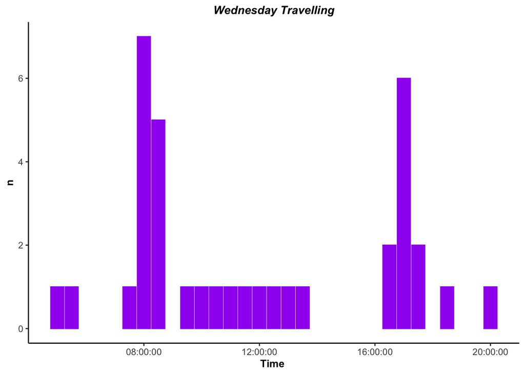

```r
#ploting Bar graph

WednesdayTransport <- ggplot(wednesdayTransport, aes(x = fixedHMS, y = n)) + geom_bar(stat = "identity", position = "stack", color="purple", fill="purple") +
  ggtitle("Wednesday Travelling") +
  xlab("Time ") +
  ylab("n") + theme(plot.title = element_text(color="Black", size=11, face="bold.italic", hjust=0.5,lineheight=0.8),
        axis.title.x = element_text(color="black", size=10, face="bold"),
        axis.title.y = element_text(color="black", size=10, face="bold"),
        panel.background=element_rect(fill = "white"),
        panel.grid.minor = element_blank(),
        panel.grid.major = element_blank(),
        axis.line = element_line(colour = "black", size = 1) +
        scale_x_date(labels = date_format("%I:%M %p"))
)

WednesdayTransport
```

```r
# Thursday
thursdayTransport <- thursday %>%
  select(fixedHMS, Activity) %>%
  filter(Activity != "Sleeping") %>%
  filter(Activity != "Rest") %>%
  filter(Activity != "Work") %>%
  filter(Activity %in% c("Driving (church)",
                         "Driving (drop kids)",
                         "Driving (drop relatives)",
                         "Driving (farm)",
                         "Driving (free time)",
                         "Driving (gym)",
                         "Driving (home)",
                         "Driving (Kava)",
                         "Driving (order delivery)",
                         "Driving (pick up kids)",
                         "Driving (visiting relatives)",
                         "Driving (work)",
                         "Public transport (home)",
                         "Public transport (work)",
                         "Public transport (school)",
                         "Walking (home)",
                         "Walking (work)",
                         "Walking (Kava)")) %>%
  group_by(fixedHMS) %>%
  tally


thursdayTransport
```

```
## # A tibble: 13 x 2
##    fixedHMS     n
##    <time>   <int>
##  1 07:00        1
##  2 07:30        1
##  3 08:00        4
##  4 08:30        1
##  5 10:30        1
##  6 11:00        1
##  7 11:30        1
##  8 12:00        1
##  9 12:30        1
## 10 16:30        2
## 11 17:00        2
## 12 17:30        2
## 13 18:00        1
```

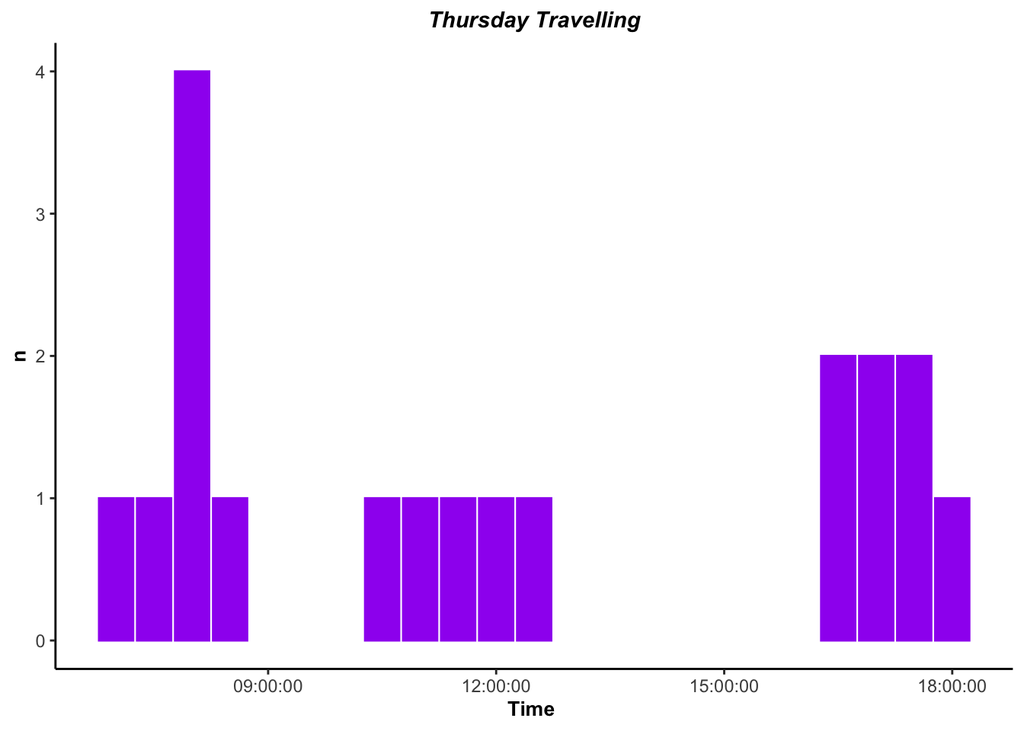

```r
#ploting Bar graph

ThursdayTransport <- ggplot(thursdayTransport, aes(x = fixedHMS, y = n)) + geom_bar(stat = "identity", position = "stack", color="purple", fill="purple") +
  ggtitle("Thursday Travelling") +
  xlab("Time ") +
  ylab("n") + theme(plot.title = element_text(color="Black", size=11, face="bold.italic", hjust=0.5,lineheight=0.8),
        axis.title.x = element_text(color="black", size=10, face="bold"),
        axis.title.y = element_text(color="black", size=10, face="bold"),
        panel.background=element_rect(fill = "white"),
        panel.grid.minor = element_blank(),
        panel.grid.major = element_blank(),
        axis.line = element_line(colour = "black", size = 1) +
        scale_x_date(labels = date_format("%I:%M %p"))
)

ThursdayTransport
```

```r
# Friday
fridayTransport <- friday %>%
  select(fixedHMS, Activity) %>%
  filter(Activity != "Sleeping") %>%
  filter(Activity != "Rest") %>%
  filter(Activity != "Work") %>%
  filter(Activity %in% c("Driving (church)",
                         "Driving (drop kids)",
                         "Driving (drop relatives)",
                         "Driving (farm)",
                         "Driving (free time)",
                         "Driving (gym)",
                         "Driving (home)",
                         "Driving (Kava)",
                         "Driving (order delivery)",
                         "Driving (pick up kids)",
                         "Driving (visiting relatives)",
                         "Driving (work)",
                         "Public transport (home)",
                         "Public transport (work)",
                         "Public transport (school)",
                         "Walking (home)",
                         "Walking (work)",
                         "Walking (Kava)")) %>%
  group_by(fixedHMS) %>%
  tally


fridayTransport
```

```
## # A tibble: 14 x 2
##    fixedHMS     n
##    <time>   <int>
##  1 05:30        1
##  2 06:30        1
##  3 07:30        2
##  4 08:00        3
##  5 08:30        3
##  6 09:00        1
##  7 10:00        1
##  8 16:30        2
##  9 17:00        4
## 10 17:30        2
## 11 18:00        1
## 12 19:00        4
## 13 19:30        1
## 14 21:30        1
```

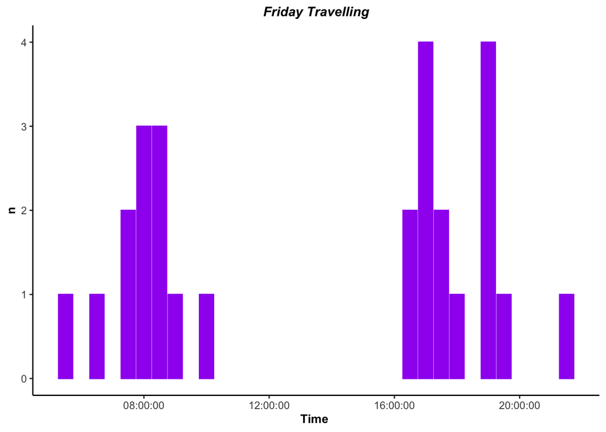

```r
#ploting Bar graph

FridayTransport <- ggplot(fridayTransport, aes(x = fixedHMS, y = n)) + geom_bar(stat = "identity", position = "stack", color="purple", fill="purple") +
  ggtitle("Friday Travelling") +
  xlab("Time ") +
  ylab("n") + theme(plot.title = element_text(color="Black", size=11, face="bold.italic", hjust=0.5,lineheight=0.8),
        axis.title.x = element_text(color="black", size=10, face="bold"),
        axis.title.y = element_text(color="black", size=10, face="bold"),
        panel.background=element_rect(fill = "white"),
        panel.grid.minor = element_blank(),
        panel.grid.major = element_blank(),
        axis.line = element_line(colour = "black", size = 1) +
        scale_x_date(labels = date_format("%I:%M %p"))
)

FridayTransport
```

```r
# Weekday
weekdayTransport <- newdata %>%
  select(fixedHMS, Activity) %>%
  filter(Activity != "Sleeping") %>%
  filter(Activity != "Rest") %>%
  filter(Activity != "Work") %>%
  filter(Activity %in% c("Driving (church)",
                         "Driving (drop kids)",
                         "Driving (drop relatives)",
                         "Driving (farm)",
                         "Driving (free time)",
                         "Driving (gym)",
                         "Driving (home)",
                         "Driving (Kava)",
                         "Driving (order delivery)",
                         "Driving (pick up kids)",
                         "Driving (visiting relatives)",
                         "Driving (work)",
                         "Public transport (home)",
                         "Public transport (work)",
                         "Public transport (school)",
                         "Walking (home)",
                         "Walking (work)",
                         "Walking (Kava)")) %>%
  group_by(fixedHMS) %>%
  tally


weekdayTransport
```

```
## # A tibble: 33 x 2
##    fixedHMS     n
##    <time>   <int>
##  1 05:00        2
##  2 05:30        2
##  3 06:30        2
##  4 07:00        4
##  5 07:30       13
##  6 08:00       40
##  7 08:30       20
##  8 09:00        4
##  9 09:30        4
## 10 10:00        5
## # … with 23 more rows
```

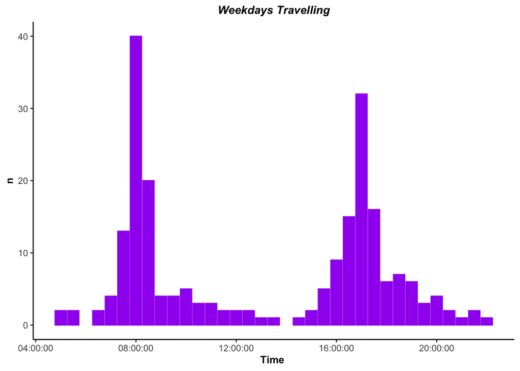

```r
#ploting Bar graph

WeekdaysTransport <- ggplot(weekdayTransport, aes(x = fixedHMS, y = n)) + geom_bar(stat = "identity", position = "stack", color="purple", fill="purple") +
  ggtitle("Weekdays Travelling") +
  xlab("Time ") +
  ylab("n") + theme(plot.title = element_text(color="Black", size=11, face="bold.italic", hjust=0.5,lineheight=0.8),
        axis.title.x = element_text(color="black", size=10, face="bold"),
        axis.title.y = element_text(color="black", size=10, face="bold"),
        panel.background=element_rect(fill = "white"),
        panel.grid.minor = element_blank(),
        panel.grid.major = element_blank(),
        axis.line = element_line(colour = "black", size = 1) +
        scale_x_date(labels = date_format("%I:%M %p"))
)

WeekdaysTransport
```

## 3.7 Monday Multiple plots

I wanted to put all the graphs in one page

```r
#graphs in one page

library(grid)
library(gridExtra)
library(gridBase)
```

> BA: I would do this a different way by re-coding and putting all the plots in one plot:

```r
# I would use data.table for this, not because it is the best way but because I know how to use it!
library(data.table)
mondayDT <- data.table::as.data.table(monday)
mondayDT[, ba_act := ifelse(Activity %in% c("Cooking",
                         "Cooking (business)",
                         "Cooking (baby)",
                         "Cooking (lunch)",
                         "Food prep (business)",
                         "Lunch",
                         "Breakfast",
                         "Dinner",
                         "Light meal/snack"),
                            "Cooking", # <- new code
                            NA)
         ]

mondayDT[, ba_act := ifelse(Activity %in% c("Tidy up",
                         "Laundry",
                         "Showering",
                         "Showering (kids)",
                         "Gardening",
                         "Getting dressed",
                         "Getting dressed (kids)",
                         "Prepare kids bag for school",
                         "Turning off applicances/Lights",
                         "Turning on appliances/lights",
                         "Ironing",
                         "Feeding animals"),
                            "Tidy up",
                            ba_act)
         ]

mondayDT[, ba_act := ifelse(Activity %in% c("Babysitting",
                         "Charging mobile devices",
                         "Family devotion",
                         "Exercise (Jog, walk)",
                         "Family time (chatting, games etc)",
                         "Homework (kids)",
                         "Kids bedtime",
                         "Listen to music/radio",
                         "Mobile devices (movies)",
                         "Mobile devices (games)",
                         "Mobile devices (work)",
                         "Mobile devices (browsing, social media)",
                         "Scripture study",
                         "Studying",
                         "Reading",
                         "Watching movies (TV)"),
                            "Leisure",
                            ba_act)
         ]

mondayDT[, ba_act := ifelse(Activity %in% c("Farm",
                         "Relatives",
                         "Work",
                         "Kava",
                         "Church",
                         "Church (social activities)",
                         "Church (choir practice)",
                         "Exercise (Jog, walk)",
                         "Gym",
                         "Sports",
                         "School",
                         "Going out"),
                            "Away",
                            ba_act)
         ]

mondayDT[, ba_act := ifelse(Activity %in% c("Driving (church)",
                         "Driving (drop kids)",
                         "Driving (drop relatives)",
                         "Driving (farm)",
                         "Driving (free time)",
                         "Driving (gym)",
                         "Driving (home)",
                         "Driving (Kava)",
                         "Driving (order delivery)",
                         "Driving (pick up kids)",
                         "Driving (visiting relatives)",
                         "Driving (work)",
                         "Public transport (home)",
                         "Public transport (work)",
                         "Public transport (school)",
                         "Walking (home)",
                         "Walking (work)",
                         "Walking (Kava)"),
                            "Transport",
                            ba_act)
         ]

t <- table(mondayDT$Activity, mondayDT$ba_act, useNA = "always")

kableExtra::kable(t, caption = "Test activity coding") %>%
  kable_styling()
```

Table 3.2: Test activity coding

|  | Away | Cooking | Leisure | Tidy up | Transport | NA |
| --- | --- | --- | --- | --- | --- | --- |
| Breakfast | 0 | 16 | 0 | 0 | 0 | 0 |
| Charging mobile devices | 0 | 0 | 1 | 0 | 0 | 0 |
| Church | 6 | 0 | 0 | 0 | 0 | 0 |
| Church (social activities) | 2 | 0 | 0 | 0 | 0 | 0 |
| Cooking | 0 | 31 | 0 | 0 | 0 | 0 |
| Cooking (baby) | 0 | 1 | 0 | 0 | 0 | 0 |
| Cooking (business) | 0 | 3 | 0 | 0 | 0 | 0 |
| Cooking (lunch) | 0 | 1 | 0 | 0 | 0 | 0 |
| Dinner | 0 | 36 | 0 | 0 | 0 | 0 |
| Driving (church) | 0 | 0 | 0 | 0 | 1 | 0 |
| Driving (drop kids) | 0 | 0 | 0 | 0 | 2 | 0 |
| Driving (drop relatives) | 0 | 0 | 0 | 0 | 1 | 0 |
| Driving (farm) | 0 | 0 | 0 | 0 | 1 | 0 |
| Driving (gym) | 0 | 0 | 0 | 0 | 4 | 0 |
| Driving (home) | 0 | 0 | 0 | 0 | 23 | 0 |
| Driving (pick up kids) | 0 | 0 | 0 | 0 | 9 | 0 |
| Driving (visiting relatives) | 0 | 0 | 0 | 0 | 10 | 0 |
| Driving (work) | 0 | 0 | 0 | 0 | 21 | 0 |
| Exercise (Jog, walk) | 4 | 0 | 0 | 0 | 0 | 0 |
| Family devotion | 0 | 0 | 12 | 0 | 0 | 0 |
| Family time (chatting, games etc) | 0 | 0 | 4 | 0 | 0 | 0 |
| Farm | 2 | 0 | 0 | 0 | 0 | 0 |
| Feeding animals | 0 | 0 | 0 | 3 | 0 | 0 |
| Getting dressed | 0 | 0 | 0 | 17 | 0 | 0 |
| Getting dressed (kids) | 0 | 0 | 0 | 5 | 0 | 0 |
| Gym | 14 | 0 | 0 | 0 | 0 | 0 |
| Home | 0 | 0 | 0 | 0 | 0 | 24 |
| Homework (kids) | 0 | 0 | 23 | 0 | 0 | 0 |
| Ironing | 0 | 0 | 0 | 7 | 0 | 0 |
| Kids bedtime | 0 | 0 | 6 | 0 | 0 | 0 |
| Laundry | 0 | 0 | 0 | 2 | 0 | 0 |
| Light meal/snack | 0 | 1 | 0 | 0 | 0 | 0 |
| Listen to music/radio | 0 | 0 | 2 | 0 | 0 | 0 |
| Mobile device (movies) | 0 | 0 | 0 | 0 | 0 | 26 |
| Mobile devices (browsing, social media) | 0 | 0 | 18 | 0 | 0 | 0 |
| Mobile devices (work) | 0 | 0 | 12 | 0 | 0 | 0 |
| Prepare kids bag for school | 0 | 0 | 0 | 1 | 0 | 0 |
| Public transport (home) | 0 | 0 | 0 | 0 | 3 | 0 |
| Public transport (work) | 0 | 0 | 0 | 0 | 2 | 0 |
| Reading | 0 | 0 | 10 | 0 | 0 | 0 |
| Rest | 0 | 0 | 0 | 0 | 0 | 18 |
| Showering | 0 | 0 | 0 | 32 | 0 | 0 |
| Sleeping | 0 | 0 | 0 | 0 | 0 | 467 |
| Tidy up | 0 | 0 | 0 | 13 | 0 | 0 |
| Turning off appliances/Lights | 0 | 0 | 0 | 0 | 0 | 2 |
| Walking (home) | 0 | 0 | 0 | 0 | 2 | 0 |
| Walking (work) | 0 | 0 | 0 | 0 | 4 | 0 |
| Watching movies (TV) | 0 | 0 | 49 | 0 | 0 | 0 |
| Woke up | 0 | 0 | 0 | 0 | 0 | 32 |
| Work | 550 | 0 | 0 | 0 | 0 | 0 |
| NA | 0 | 0 | 0 | 0 | 0 | 0 |

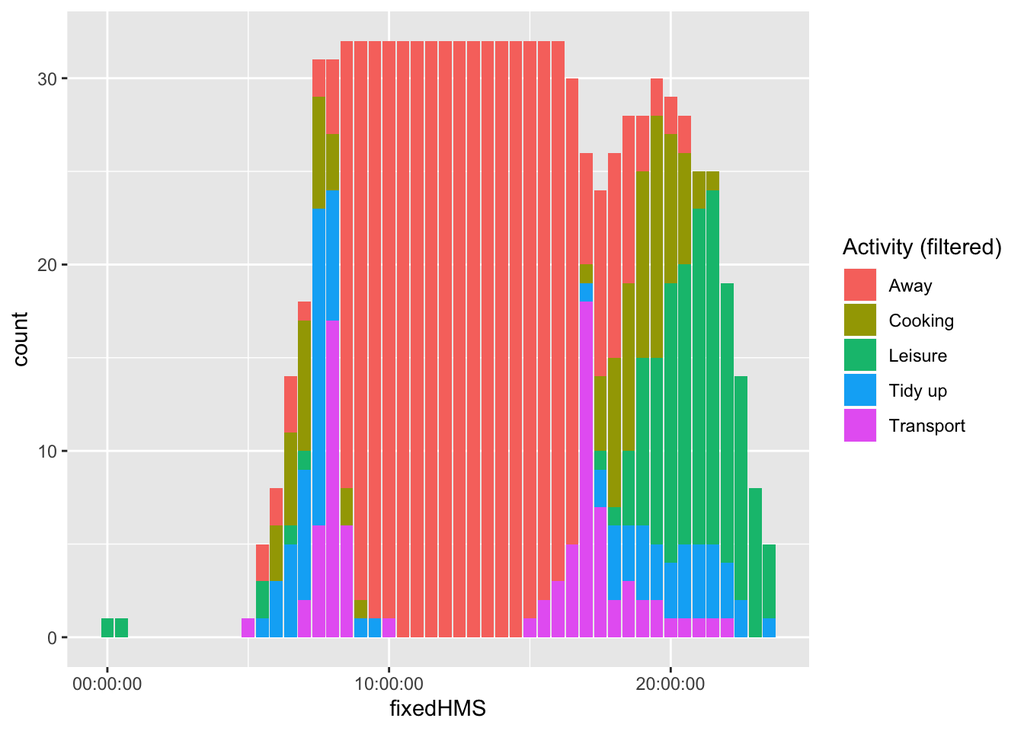

```r
# make a summary table for the plot
plotDT <- mondayDT[!is.na(ba_act), # excludes all NAs - see table to check coding
                   .(count = .N), keyby = .(fixedHMS, ba_act)]

ggplot2::ggplot(plotDT, aes(x = fixedHMS, y = count, fill = ba_act)) +
  geom_col() +
  scale_fill_discrete(name="Activity (filtered)")
```